# HER2 patient subtyping in TCGA breast cancer

*Claude Code was run in manual mode using Opus 5.5. The PI reviewed all code and analytical choices.*

# Key findings

- **RNA is the better molecular readout.** ERBB2 mRNA tracks clinical IHC better than DNA copy number: modestly for IHC 3+ (AUC 0.927 vs. 0.893), clearly for HER2-low vs. HER2-0 (0.685 vs. 0.573) (Section 2.3).
- **Patients who may be mislabelled.** 19 ERBB2-amplified tumors were called HER2− or left unresolved. Two IHC-negative tumors with very high ERBB2 mRNA are priority re-testing candidates (Sections 2.3, 3.2).
- **A candidate exploratory population with a distinct biological profile.** 83 tumors (8% of the cohort; “C5 ERBB2-low”) cluster with HER2-enriched disease but are mostly not HER2-driven: rarely amplified, with luminal-level ERBB2 mRNA. Most are ER+ by IHC (78%) yet have a weak ER program, and they are heavily immune-infiltrated (Sections 3–5).
- **Why it matters.** HER2-low status, and with it trastuzumab deruxtecan eligibility, is common in every subtype, so this group is not unique on eligibility. Its distinct biology makes it a candidate for exploratory study of response to ADCs and endocrine therapy in a cohort with outcomes (Section 6).
- **Data quality.** HER2 status recorded without an IHC score was unreliable at two sites; analyses use scored IHC (Section 2.2).
- **Limitations.** Bulk RNA-seq, one cohort, no treatment outcomes: hypotheses for validation.

# Main results

## 1. QC and normalization

### 1.1 Input and normalization

RNA-seq covers 1,212 samples (1,093 primary tumor, 112 adjacent normal, 7 metastasis) and 20,502 genes. The values are TCGA upper-quartile (UQ) scaled RSEM rather than raw counts, so read depth is already scaled out **(Figure S1)**.

Values were rounded, and genes with ≥10 counts in ≥10% of samples were kept (16,453 genes). A blind DESeq2 variance-stabilizing transform (VST) was then applied. DESeq2’s size factors sit near 1, so they change little beyond the UQ scaling. Because the inputs are scaled rather than true counts, VST is an approximate stabilizer here, and later differential expression uses limma on VST values. No sample was an outlier.

### 1.2 Sources of variation

Across all samples, adjacent normals separate from tumors. ER-negative tumors form a distinct cluster with high basal-marker expression, consistent with the basal-like subtype **(Figure 1)**.

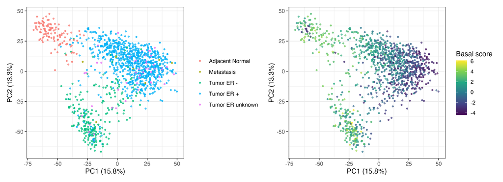

**Figure 1.** PCA of all samples (VST, top 2,000 variable genes). Left: sample type and, for primary tumors, ER status by IHC. Right: basal score (mean centered VST of KRT5, KRT14, KRT17, FOXC1); normals also score high because of myoepithelial cells.

Within primary tumors, PC1–5 were each regressed on clinical and technical features (adjusted R²) **(Figure 2)**:

- **PC1 (16.6%)** is the ER/PR axis (luminal vs. basal), consistent with the TCGA intrinsic subtypes [1].
- **PC2 (7.9%)** tracks fraction genome altered and lobular vs. ductal histology, and possibly tumor purity [2, 3].
- **PC3 (4.3%)** mixes HER2 biology (ERBB2 copy number, HER2 IHC) with plate.
- **PC4 (3.6%)** is mainly plate and processing era. **PC5** is weak.

Only PC1–2 are stable across transforms (correlation with PCs from a log2(UQ+1) transform), so only they are interpreted firmly **(Table S1)**.

HER2 IHC has no association with PC1. Its ERBB2 copy-number association (adjusted R² 0.10) likely reflects copy losses in basal tumors rather than amplification. HER2+ tumors therefore occur in both ER+ and ER− disease, and clinical HER2+ differs from the HER2-enriched subtype [4]. Global variance alone cannot define HER2+, which motivates the targeted definitions in Step 2.

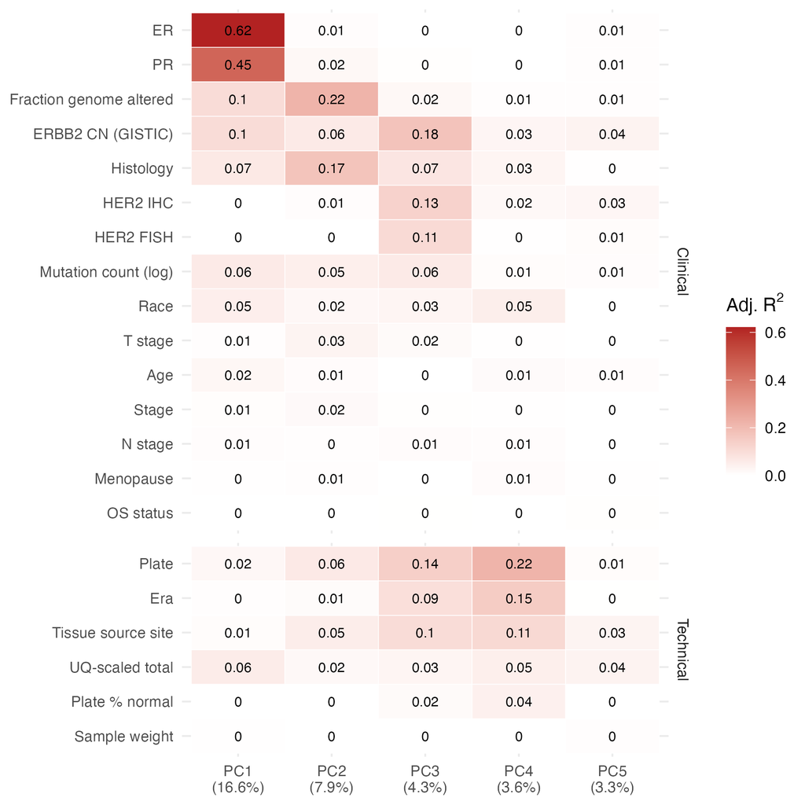

**Figure 2.** Variance in each primary-tumor PC explained by clinical and technical features (adjusted R², linear model; negative values shown as 0). Percent variance per PC is shown under each axis label. Era: plates before A213 vs. plate A213 and after.

### 1.3 Processing batch

Plate effects are mainly a step between two processing eras at plate A213 **(Figure S2)**, consistent with large plate effects in TCGA RNA-seq [5]. Era is confounded with biology: 110 of 112 normals are in the earlier era, and later-era tumors are far more often lobular (43% vs. 12%) **(Table S2)**. After accounting for biology, plate still explains 0.09 of PC3 and 0.2 of PC4 (adjusted partial R²) **(Table S4)**.

**Decision: no plate correction.** Correction would remove real biology along with era, and protecting the clinical labels instead would overstate group differences [6]. ER, PR and HER2 signal barely depends on plate **(Supplement S3)**. Downstream, era and histology are sensitivity covariates (Steps 2 and 4), clusters are tested against era within histology (Step 3), and tumor–normal comparisons are made within patients (Section 5.5).

## 2. Identifying HER2+ patients

### 2.1 Clinical HER2 status

TCGA records two IHC fields for HER2: a numeric IHC score (0–3+) and a reported IHC status (Negative/Equivocal/Positive). It also records a FISH result for some tumors. The sites made these calls under the ASCO/CAP criteria of the time (2007 or 2013) [7, 8]. Rules modelled on the current 2018 guideline [9] were applied to them:

- **IHC 3+** is HER2+.
- **IHC 2+** takes its status from FISH, and stays unresolved without it.
- **IHC 0/1+** is HER2−. If FISH is positive, the tumor is unresolved, because under 2018 rules it is positive only in ISH group 1, which cannot be checked here.
- **The reported status** is used only when there is no score. It may record the final HER2 call rather than the IHC reading, so a reported Positive with negative FISH is unresolved.
- **Score vs. reported status:** when both exist, each is turned into a call. A reported Equivocal with negative FISH counts as negative. If the two calls are opposite, the tumor is a conflict and is excluded. Otherwise the score wins.

HER2− tumors with a numeric score were split into HER2-0 and HER2-low (IHC 1+, or 2+ with negative FISH). HER2-low is the group that trastuzumab deruxtecan opened to HER2-directed therapy [10, 11, 12].

Of 1,093 primary tumors, 170 are HER2+ and 759 are HER2− **(Table 1)**. Another 33 are unresolved, 14 are conflicts, and 117 have neither IHC nor FISH. Most HER2− tumors with a score are HER2-low (394 of 455). The rule behind each label is listed in **(Table S5)**, and every disagreement between sources, with its resolution, in **(Table S6)**.

**Table 1.** Clinical HER2 status of 1,093 primary tumors, from 2018-style rules applied to the reported IHC score, IHC status and FISH. HER2− tumors with a numeric IHC score are split into HER2-0 and HER2-low. Conflict: IHC score and reported IHC status give opposite calls (excluded).

| HER2 status | Subgroup | Tumors |
| --- | --- | --- |
| Positive |  | 170 |
| Negative | HER2-0 | 61 |
| Negative | HER2-low (1+) | 256 |
| Negative | HER2-low (2+/FISH-) | 138 |
| Negative | No IHC score | 304 |
| Unresolved |  | 33 |
| Conflict |  | 14 |
| Missing |  | 117 |

ERBB2 mRNA rises step by step from IHC 0 to 3+ **(Figure 3)**. Most 3+ tumors are amplified (GISTIC 2) with high mRNA. Still, 61 of 151 HER2+ tumors with copy-number data are not amplified (23 have a low-level gain). Most come from three sources: IHC 2+/FISH+ tumors (19; probably borderline FISH results, some of which 2018 rules would call negative), reported status only (20; a noisy label, Section 2.2), and site A8 (7) **(Supplement S8)**. Low tumor purity does not explain the gap (ESTIMATE score, amplified vs. non-amplified, Wilcoxon p = 0.32) **(Supplement S4)**.

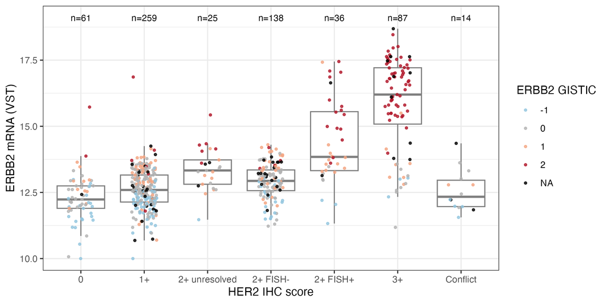

**Figure 3.** ERBB2 mRNA (VST) by HER2 IHC score, colored by ERBB2 copy number (GISTIC). IHC 2+ is split by FISH (‘2+ unresolved’: no informative FISH). The 1+ group includes 3 FISH+ tumors that are unresolved in Table 1. Conflict: IHC score and reported IHC status disagree (Table 1). Tumors without a numeric score (n = 473) are not shown; most (290) have a reported IHC status (Section 2.2). ERBB2 values below 10 are shown at 10 (n = 2).

### 2.2 Reported IHC status is a noisy label at some sites

Where only a reported IHC status exists, it is a poor stand-in for the IHC score. Each raw predictor (ERBB2 mRNA or GISTIC copy number) was scored against the IHC label by AUC, without a model. With a numeric score, both separate IHC 3+ from 0/1+ well (AUC 0.93 for mRNA, 0.90 for copy number). With only a reported status, both are barely better than chance (0.64 and 0.60) **(Figure 4, Table S7)**. The noise is in the reported Positives, many of which have low mRNA and no amplification.

These reported Positives cluster in two tissue source sites: BH and E9 account for 23 of the 31, and only 7 of those 23 are amplified **(Table S8)**. Excluding the two sites (chosen after inspection, so exploratory) raises the mRNA AUC to 0.85, but only 8 positives remain. The likely cause is site practice, such as recording a final or older-criteria HER2 call in the IHC field. TCGA clinical data are known to vary in quality across sites [13], although that work did not examine HER2 fields.

**Consequence:** the main IHC target in Section 2.3 uses the numeric score only (3+ vs. 0/1+). Reported-status tumors are added back as a sensitivity analysis.

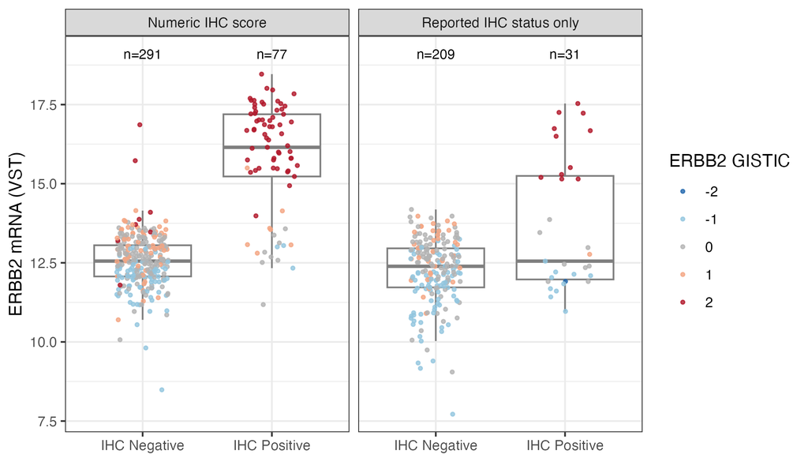

**Figure 4.** ERBB2 mRNA (VST) in IHC-positive (3+) and IHC-negative (0/1+) tumors, by label source, colored by ERBB2 copy number (GISTIC). Tumors with copy-number data only.

### 2.3 Is RNA or DNA more predictive of IHC?

**Design.** ERBB2 mRNA (VST) was compared with ERBB2 copy number (GISTIC, five ordered levels) on the same tumors. FISH helps define the clinical label, so it was not used as a DNA predictor. Each predictor is a single ordered value, so the pre-specified primary test needs no model: the raw-value AUCs (as in Section 2.2) were compared with a paired DeLong test **(Table 2)**.

Logistic regression was then used to model and combine predictors, fitted to all 366 tumors of the main target. The RNA model is a univariable logistic regression on ERBB2 mRNA; the DNA and RNA + DNA models are:

$$\textbf{DNA:}\quad \operatorname{logit}
P(\text{IHC 3+}) = \beta_0 + \gamma_0\,[\text{CN}=0] +
\gamma_1\,[\text{CN}=1] + \gamma_2\,[\text{CN}=2]$$

$$\textbf{RNA + DNA:}\quad
\operatorname{logit} P(\text{IHC 3+}) = \beta_0 + \beta_1\,\text{ERBB2}
+ \gamma_0\,[\text{CN}=0] + \gamma_1\,[\text{CN}=1] +
\gamma_2\,[\text{CN}=2]$$

In these equations:

- **ERBB2** is mRNA in VST units (about log2), with coefficient $\beta_1$.
- **CN** is GISTIC copy number, entered as indicators $[\text{CN}=c]$ (1 if the tumor has level $c$) with coefficients $\gamma_c$. Loss (−1/−2) is the reference.
- **$\beta_0$** is the intercept.

Fitted values are in **(Table S11)**:

- **RNA model:** $\beta_1$ = 1.66, so each VST unit multiplies the odds of IHC 3+ by 5.3.
- **DNA model:** the amplification term is $\gamma_2$ = 5.29.
- **RNA + DNA model:** once mRNA is included, $\gamma_2$ shrinks to 0.28 and its 95% CI includes 0, while $\beta_1$ stays at 1.50.

Model performance was estimated by stratified cross-validation (CV): 5 folds × 10 repeats for exploration, and 10 folds × 10 repeats for the selected model. AUC was computed within each test fold and then averaged. Models were compared with the corrected repeated k-fold t-test, BH-adjusted across all comparisons **(Supplement S7)**.

**Result: RNA is modestly more predictive than DNA for IHC 3+, and clearly better for HER2-low** **(Table 2, Figure 5)**. For the main target (366 tumors, 76 IHC 3+), the raw AUC is 0.927 for mRNA vs. 0.893 for copy number (paired DeLong p = 0.045), and the CV logistic models agree in direction (corrected t-test p = 0.03, BH-adjusted 0.18). For HER2-low vs. HER2-0 and for IHC 1+ vs. 0, RNA leads clearly (0.685 vs. 0.573, paired DeLong p = 0.001; 0.652 vs. 0.554, p = 0.008), including within ER+ tumors. Results by target, era and ER status are in **(Supplement S6)**.

**Combining does not help** **(Table S12, Table S13, Figure S5)**. In CV logistic models, adding copy number, ER/PR, the 17q12 co-amplified genes, tumor purity, or era and histology to the mRNA-based models does not significantly change the AUC (all BH-adjusted p ≥ 0.22). Clinical variables (age, race, ER, PR, histology, era) add nothing beyond mRNA and copy number either, and no interaction is significant (likelihood-ratio tests, BH-adjusted) **(Supplement S5)**. The selected model is therefore the univariable RNA model, with a 10-fold CV AUC of 0.927. Because the label is IHC, a protein readout, it may favor mRNA over copy number **(Supplement S6)**.

**Table 2.** Primary RNA vs. DNA test: raw-value AUC of ERBB2 mRNA (RNA) and ERBB2 copy number (DNA, GISTIC) for each HER2 target, compared by paired DeLong test (no model fitted). Positive: IHC 3+, HER2+, HER2-low or IHC 1+, by target. Complete cases for ER, PR, histology and purity.

| Target | Subset | Tumors | Positive | AUC RNA | AUC DNA | Difference (95% CI) | p |
| --- | --- | --- | --- | --- | --- | --- | --- |
| IHC score 3+ vs 0/1+ (main) | All | 366 | 76 | 0.927 | 0.893 | 0.033 (0.001 to 0.066) | 0.045 |
| IHC 3+ vs 0/1+, incl. reported status | All | 603 | 107 | 0.837 | 0.808 | 0.028 (-0.001 to 0.058) | 0.057 |
| Clinical status (FISH-resolved) | All | 814 | 150 | 0.839 | 0.813 | 0.026 (0.001 to 0.050) | 0.040 |
| HER2-low vs HER2-0 | All | 406 | 346 | 0.685 | 0.573 | 0.112 (0.043 to 0.181) | 0.001 |
| IHC 1+ vs 0 (HER2-) | All | 287 | 227 | 0.652 | 0.554 | 0.098 (0.025 to 0.171) | 0.008 |
| HER2-low vs HER2-0 | ER+ only | 320 | 278 | 0.655 | 0.559 | 0.096 (0.006 to 0.185) | 0.036 |
| IHC score 3+ vs 0/1+ (main) | Plates before A213 | 323 | 68 | 0.936 | 0.910 | 0.026 (-0.008 to 0.060) | 0.130 |
| IHC score 3+ vs 0/1+ (main) | Plate A213 and after | 43 | 8 | 0.818 | 0.736 | 0.082 (-0.047 to 0.211) | 0.211 |

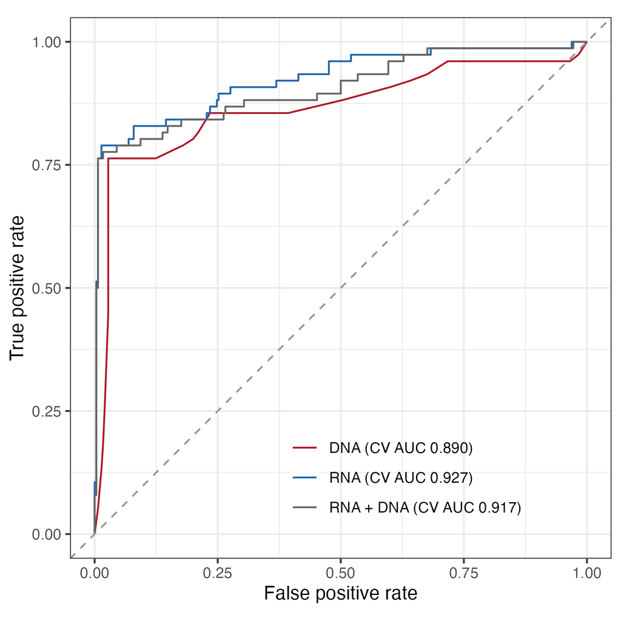

**Figure 5.** ROC curves for predicting IHC 3+ vs. 0/1+ (numeric score; n = 366) from the RNA, DNA and RNA + DNA logistic models (equations in Section 2.3). Stratified 10-fold CV; curves show pooled out-of-fold predictions from the first of 10 repeats. Legend: mean AUC over test folds and repeats.

**Tumors where the model and IHC disagree.** Out-of-fold predictions from the molecular logistic model (ERBB2 mRNA + GISTIC + ER + PR) **(Supplement S7)** disagree strongly with IHC (IHC 3+ with predicted probability < 0.2, or IHC 0/1+ with > 0.8) for 18 scored tumors **(Table S14)**. Two IHC-negative tumors are amplified with very high mRNA, TCGA-A2-A0YJ-01 (IHC 0) and TCGA-A8-A08J-01 (IHC 1+, FISH−), and are candidates for HER2 re-testing. The other 16 are IHC 3+ without amplification or high mRNA. Six come from site A8 (all FISH+), which points to site-level annotation problems, and four are later-era lobular tumors, which points to IHC over-scoring **(Supplement S8)**.

## 3. Patient subsets from unsupervised clustering

### 3.1 Five expression clusters

The 1,093 primary tumors were clustered by PAM (partitioning around medoids) on the 2,000 most variable genes (uncorrected VST, re-ranked on tumors; genes mean-centered; distance 1 − Pearson correlation). The number of clusters, k, was chosen from the average silhouette width (how well tumors fit their own cluster) and consensus stability over 200 resamples (PAC; lower is more stable) **(Figure S6, Supplement S9)**. k = 2 is best on both but only separates basal tumors from the rest. k = 5 is a local silhouette maximum with PAC (0.23) below k = 3–4. Silhouettes are below 0.19 and PAC is above 0.18 at every k, so the clusters are regions of a continuum rather than discrete groups. Each cluster is named by its most common PAM50 subtype, assigned with the PAM50 centroid classifier [14].

The five clusters recover the intrinsic subtypes **(Figure 6, Table 3)**:

- **C4 (Basal):** ER− with basal keratins and FOXC1. It is the most distinct cluster (median silhouette 0.39).
- **C5 (Her2):** high ERBB2 and its amplicon neighbors GRB7 and STARD3, in about half its tumors (Section 3.2).
- **C1 (LumB):** proliferative luminal tumors.
- **C2 (LumA):** low proliferation with high stromal and immune expression. About half are lobular, resembling the reactive-like and immune-related lobular subtypes [2].
- **C3 (LumA):** a luminal A/B mix with the highest purity.

Agreement with PAM50 is moderate (adjusted Rand index 0.37), mostly because the luminal clusters divide the luminal A/B continuum differently. C4 and C5 are the most reproducible across gene sets and consensus clustering; the luminal clusters shift most **(Table S16)**. Within histology, cluster is associated with processing era, largely through case mix (later-era ductal tumors are more often ER− by IHC); a residual association among ER+ ductal tumors is a caveat **(Supplement S10)**.

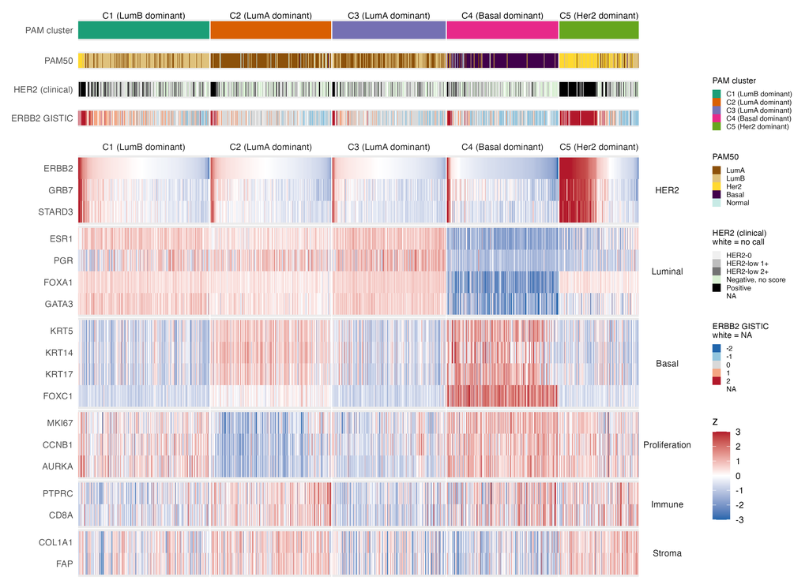

**Figure 6.** Marker genes by PAM cluster (VST, z-scored per gene, capped at ±3). Tumors are ordered by cluster, then by ERBB2 mRNA. Top tracks: PAM cluster (colors as in Figure 7), PAM50 subtype, clinical HER2 category (Table 1; white = no call) and ERBB2 copy number (GISTIC; colors as in Figure 7).

### 3.2 Clusters and HER2 status

HER2 status differs between clusters (chi-square, simulated p <0.001, BH-adjusted; bias-corrected Cramér’s V 0.44) **(Table 3, Figure 7)**.

**HER2+ tumors fall into two groups.** 80 of the 170 HER2+ tumors (47%) are in C5. Of the other 90, 80 are in the luminal clusters, the largest share in C1 (39). Clinical HER2+ disease spans several intrinsic subtypes [4, 15].

**C5 has two ERBB2 levels, explained by copy number.** ERBB2 mRNA in C5 has two modes, separated at the kernel density minimum (14.92 VST); a two-component Gaussian mixture fits much better than one (BIC) **(Figure 7, Supplement S11)**.

- **ERBB2-high (73 tumors):** classic HER2+ disease. 64 of 66 with copy-number data are amplified, and all 67 with a clinical call are HER2+.
- **ERBB2-low (83 tumors):** rarely amplified (5 of 70). Their ERBB2 mRNA (median 12.6) is at the level of the luminal clusters (12.9). 59 are HER2−, 13 HER2+ (mostly borderline or noisy labels from Section 2) **(Table S22)** and 11 have no call. They are more often ER+ (78% vs. 53%, Fisher p = 0.002), have mixed PAM50 calls (27 Her2, 36 LumB, 17 LumA, 3 other), and fit C5 loosely (median silhouette 0.05 vs. 0.09), sitting at its edge.

**The ERBB2-low group is heavily infiltrated.** Its median ESTIMATE score (stromal plus immune signal; higher = lower purity) is 675 vs. 9 in ERBB2-high (Wilcoxon p <0.001), with more stromal and far more immune marker expression **(Table S20)**. Its ERBB2 mRNA falls as purity drops (Spearman ρ = -0.30, vs. -0.04 in ERBB2-high), so infiltration dilutes part of its ERBB2 signal.

**Three amplified ERBB2-low tumors lack a HER2+ call.** Of the 5 amplified tumors in the group, 2 are FISH+ and HER2+. The other 3 are TCGA-C8-A26X-01 (IHC 1+, called HER2-low) and TCGA-C8-A138-01 and TCGA-C8-A1HL-01 (IHC 2+, no FISH; unresolved). Their ERBB2 mRNA (13.6–14.1 VST) lies between the luminal level and that of amplified HER2+ tumors (median 16.6). Two are less pure than the group median (ESTIMATE 1,847 and 1,290 vs. 675), so infiltration may hide part of their signal. They are among 19 amplified tumors called HER2− or unresolved, with the two tumors from Section 2.3 (in C4 and C1) **(Table S15)**; several of the others (e.g. IHC 2+ without FISH) have higher ERBB2 mRNA and equally merit ISH. A further 10 amplified tumors have no clinical HER2 data.

**HER2-low is common in every cluster.** Among HER2− tumors with a numeric IHC score, 79–91% are HER2-low in each cluster, with no clear difference between clusters (chi-square, simulated p = 0.066). HER2-low is least common in C4 (Basal), in line with HER2-low being more frequent in HR+ than HR− disease [16, 17]. All 34 scored HER2− tumors in C5 are in its ERBB2-low group, and 31 of them are HER2-low. These rates are well above published ones [16, 17], probably because some IHC 0 tumors were recorded as “Negative” without a score: the 304 HER2− tumors without a score have ERBB2 mRNA between scored HER2-0 and 1+ (median 12.5 vs. 12.2 and 12.6). Whether HER2-low is a distinct biological entity is debated [12, 16, 17]; no cluster here is specific to it.

**Table 3.** PAM clusters. HER2+: % of tumors with a HER2+ or HER2− call (Table 1). Amplified: % with GISTIC 2 among tumors with copy-number data. HER2-low: % of HER2− tumors with a numeric IHC score (likely inflated; see Section 3.2). ESTIMATE: higher = lower purity. Silhouette: how well each tumor fits its cluster (−1 to 1).

| Cluster | Tumors | Top PAM50 (%) | HER2+ (%) | Amplified (%) | ER+ (%) | Lobular (%) | HER2-low (% of scored HER2−) | ESTIMATE (median) | Silhouette (median) |
| --- | --- | --- | --- | --- | --- | --- | --- | --- | --- |
| C1 (LumB) | 258 | 76 | 19 | 10 | 99 | 9 | 90 | -830 | 0.06 |
| C2 (LumA) | 237 | 82 | 11 | 4 | 95 | 49 | 90 | 548 | 0.12 |
| C3 (LumA) | 223 | 57 | 9 | 4 | 99 | 21 | 85 | -976 | 0.06 |
| C4 (Basal) | 219 | 88 | 5 | 5 | 19 | 2 | 79 | -198 | 0.39 |
| C5 (Her2) | 156 | 57 | 58 | 51 | 66 | 9 | 91 | 428 | 0.07 |

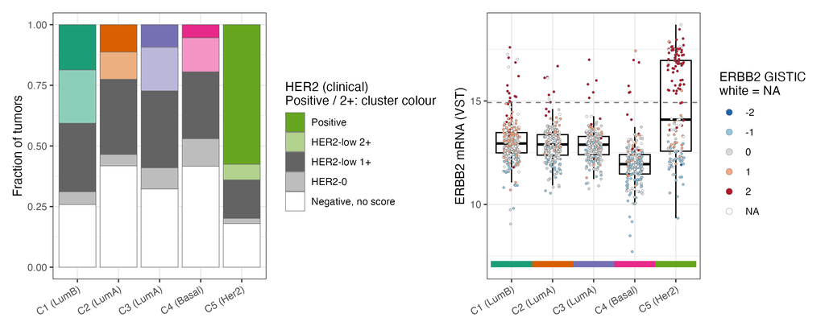

**Figure 7.** Left: clinical HER2 category by PAM cluster, stacked (top to bottom) as HER2+ (cluster color), HER2-low 2+ (lighter cluster color), HER2-low 1+, HER2-0, and HER2− without a numeric score. Right: ERBB2 mRNA (VST) by cluster, points colored by ERBB2 copy number (GISTIC, as in Figure 6); bottom strip: cluster color. Dashed line: density minimum separating the ERBB2-high and ERBB2-low groups in C5.

## 4. What sets the C5 ERBB2-low group apart

The C5 ERBB2-low group is not amplified, has luminal-level ERBB2 mRNA, and is mostly HER2-low among scored HER2− tumors, yet PAM placed it in C5. This section asks which genes separate it from the amplified tumors in its own cluster (C5 ERBB2-high) and from luminal disease (clusters C1–C3, pooled). C4 (Basal) is shown for reference only.

### 4.1 Models

**Elastic net for feature selection.** Each contrast was modelled by elastic net logistic regression, with C5 ERBB2-low as the positive class (83 tumors) against C5 ERBB2-high (73) or C1–C3 (717; one tumor without histology was excluded so that all models use the same tumors):

$$\operatorname{logit} P(\text{C5
ERBB2-low}) = \beta_0 + \delta\,\text{Purity} + \sum_{j}
\beta_j\,\text{gene}_j$$

- **gene$_j$:** mRNA (uncorrected VST) of the 5,000 most variable genes across primary tumors. ERBB2 is left out of the C5-high contrast because the two C5 groups were defined by ERBB2 mRNA.
- **Purity:** ESTIMATE score / 1,000, with coefficient $\delta$. Tumor purity confounds expression analyses [3] and this is the least pure group, so purity is not penalized: genes are selected for what they add beyond it.
- **Penalty:** the gene coefficients $\beta_j$ are shrunk by $\lambda \sum_j \left[\tfrac{1-\alpha}{2}\beta_j^2 + \alpha\,|\beta_j|\right]$ with $\alpha$ = 0.5, which keeps correlated genes together while still selecting few. $\lambda$ is chosen by inner 10-fold CV (largest $\lambda$ within one standard error of the best).

**Selection frequency.** The model was refitted in each of the 100 training sets of a 5-fold × 20-repeat stratified CV. A gene is **stable** if selected in ≥70% of them (a descriptive cut-off without error control). The held-out folds give the AUC, averaged over test folds, with a 95% CI from the corrected repeated k-fold t-test.

**Compact logistic model for prediction.** The $m$ genes with the largest coefficients in each training set’s elastic net were refitted as an ordinary logistic regression:

$$\operatorname{logit} P(\text{C5
ERBB2-low}) = \beta_0 + \delta\,\text{Purity} + \sum_{j=1}^{m}
\beta_j\,z_j$$

where $z_j$ is gene $j$ z-scored within the contrast, so $e^{\beta_j}$ is the odds ratio per standard deviation. $m$ is the smallest number within 0.01 AUC of the best. The CV AUC rates this gene-picking procedure, not one fixed gene set. The final model uses the $m$ genes the procedure picked most often, fitted on all tumors by Firth’s penalized logistic regression **(Supplement S12)**.

**Caveat: AUCs are high by construction.** The clusters and the C5 split were defined from many of these same genes. AUC here measures how few genes describe a group, not a validated classifier.

### 4.2 Results

**Against amplified C5, the amplicon is sufficient.** 22 genes are stable **(Figure 8, Table S23)**. Ten of the 14 genes lower in the ERBB2-low group lie in the 17q12 ERBB2 amplicon (STARD3, GRB7, PGAP3, MIEN1, MED1, CDK12, ORMDL3, PSMD3, PNMT, MED24). This mainly confirms the split, since the groups were defined by ERBB2 mRNA. STARD3 was the top gene in 94% of training sets, and a one-gene compact model reaches a CV AUC of 0.996 **(Table 4)**. Because the amplicon separates the groups almost perfectly, other differences (ER status, infiltration) are not needed by the model; Step 5 compares the groups gene by gene.

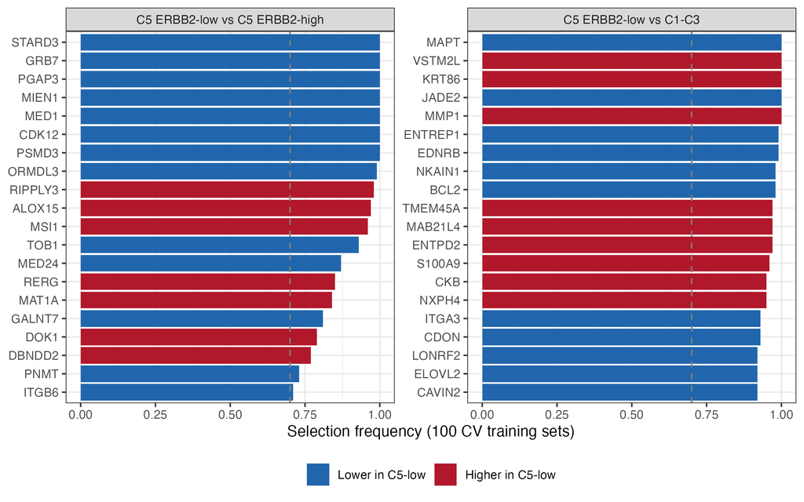

**Figure 8.** The 20 genes most often selected by the elastic net in each contrast, out of 100 CV training sets (ties ordered by coefficient size; current gene symbols). Color: direction in C5 ERBB2-low relative to the comparator. Dashed line: 70% stability cut-off.

**Against the luminal clusters, a weaker luminal program.** 43 genes are stable **(Figure 8, Figure S8)**:

- **Lower luminal genes:** ER-associated genes, including the PAM50 genes PGR, BCL2 and MAPT [14], and GFRA1, ELOVL2 and SERPINA3, are about 2 VST units lower than in luminal tumors even though 78% of the group is ER+ by IHC. They stay lower against purity-matched luminal tumors (the 3 nearest by ESTIMATE per tumor) **(Table S25)**.
- **Shift toward non-luminal expression:** genes such as VSTM2L, KRT86, MMP1 and S100A9 are higher, placing the group between luminal tumors and C5 ERBB2-high/C4, a shift also seen when luminal tumors progress to metastasis [18].
- **ERBB2 adds nothing:** ERBB2 mRNA with purity (CV AUC 0.748) does no better than purity alone (0.749).

**A 7-gene compact model captures most of the signal** **(Table 4, Figure S9)**. With purity, it reaches a CV AUC of 0.964, beating purity alone by 0.215 (corrected t-test, BH-adjusted p <0.001) and falling 0.021 short of the full elastic net (BH-adjusted p = 0.010). The final model’s genes are VSTM2L, KRT86, MMP1 and TMEM45A (higher) and MAPT, JADE2 (PHF15) and BCL2 (lower), with odds ratios per SD from 0.27 (MAPT) to 3.29 (VSTM2L) **(Table S24)**. Only VSTM2L and MAPT were picked almost every time (98% and 96%); many near-equivalent gene sets exist, as expected for correlated genes **(Supplement S12)**.

**Table 4.** Cross-validated AUC of the logistic models (Section 4.1): mean over test folds of 5-fold × 20-repeat stratified CV, with corrected repeated k-fold t-test 95% CI (upper limit capped at 1). Elastic net: all 5,000 genes, purity unpenalized. Compact: plain logistic regression on the top elastic net genes of each training set.

| C5 ERBB2-low vs. | Model | CV AUC (95% CI) |
| --- | --- | --- |
| C5 ERBB2-high | Purity only | 0.665 (0.587–0.742) |
| C5 ERBB2-high | Compact (top 1 gene) + purity | 0.996 (0.986–1.000) |
| C5 ERBB2-high | Elastic net (all genes) + purity | 0.999 (0.997–1.000) |
| C1-C3 | ERBB2 mRNA + purity | 0.748 (0.696–0.800) |
| C1-C3 | Purity only | 0.749 (0.698–0.801) |
| C1-C3 | Compact (top 7 genes) + purity | 0.964 (0.946–0.983) |
| C1-C3 | Elastic net (all genes) + purity | 0.985 (0.975–0.994) |

The C5 ERBB2-low group is therefore not HER2-driven: it has no amplicon and no high ERBB2, and the 7-gene model describes membership of this group, not HER2-low status. Step 5 tests the programs behind these genes (ER signalling, proliferation, hypoxia, immune).

## 5. Biology of the C5 ERBB2-low group

This section asks what biology separates the C5 ERBB2-low group, gene by gene and pathway by pathway, against the same two comparators: the luminal clusters (C1–C3, pooled) and C5 ERBB2-high. It also estimates immune and stromal cell content and compares the group with its matched normal tissue.

### 5.1 Methods

**Differential expression.** Each gene was modelled across all primary tumors with limma on the uncorrected VST (moderated t-statistics with an intensity trend, robust to outlying variances):

$$\text{VST}_{gi} = \sum_{c}
\mu_{gc}\,\mathbb{1}[\text{group}_i = c] + \gamma_g\,\text{Stromal}_i +
\eta_g\,\text{Immune}_i + \varepsilon_{gi}$$

- **group:** C1, C2, C3, C4, C5 ERBB2-high or C5 ERBB2-low; $\mu_{gc}$ is the mean of gene $g$ in group $c$. Keeping C1–C3 separate stops their differences from inflating the residual variance.
- **Contrasts:** C5 ERBB2-low vs. C1–C3 is $\mu_{\text{low}} - \sum_{c \in \text{C1–C3}} w_c\,\mu_c$, with $w_c$ the share of the 718 luminal tumors in cluster $c$ (the pooled luminal mean). C5 ERBB2-low vs. C5 ERBB2-high is $\mu_{\text{low}} - \mu_{\text{high}}$.
- **Stromal, Immune:** the two ESTIMATE component scores (/1,000). The **unadjusted** model leaves them out and shows every difference, infiltration included. The **purity-adjusted** model includes them and asks what differs at equal infiltration. ESTIMATE is itself built from stromal and immune genes, so this adjustment is approximate, not a deconvolution.
- **Significant genes:** TREAT, a moderated t-test of whether |log2 fold change| exceeds 1, BH-adjusted p < 0.05. Where a p-value for any difference is quoted, it is the ordinary moderated t-test (BH).

**Pathways.** Gene set enrichment analysis (fgsea) ranked all genes by the moderated t of each contrast and tested the 50 MSigDB Hallmark sets (normalized enrichment score, NES; positive = higher in C5 ERBB2-low; BH-adjusted p). fgsea ignores correlation between genes and, with about 800 tumors, calls almost any coherent program significant. Each Hallmark result was therefore checked with camera on the same design, using limma’s small default inter-gene correlation and, more strictly, each set’s estimated correlation. A program significant with the estimated correlation is called **camera-confirmed** **(Table S28, Supplement S13)**.

**Immune and stromal cells.** Each tumor’s abundance of 8 immune and 2 stromal populations was scored by MCP-counter (mean VST of population-specific marker genes) **(Supplement S13)**. Groups were compared, within each contrast, by a linear model with heteroskedasticity-robust (HC3) standard errors:

$$\text{Score}_i = \beta_0 +
\beta_1\,\text{C5 ERBB2-low}_i + \gamma\,\text{Stromal}_i +
\eta\,\text{Immune}_i + \varepsilon_i$$

where C5 ERBB2-low$_i$ is 1 for tumors in the group and 0 for the comparator, and $\beta_1$ is the difference in score (VST units). Without the ESTIMATE terms, $\beta_1$ is the plain difference in abundance; with them, it shows each population **relative to the ESTIMATE stromal and immune signal**. p-values are BH-adjusted across the 20 tests of each model (10 populations × 2 comparators).

**Tumor vs. matched normal tissue.** Only 11 of the 83 C5 ERBB2-low tumors have an adjacent normal sample from the same patient; their purity shows no detectable difference from the rest of the group (Wilcoxon, underpowered) and their PAM50 mix is similar **(Supplement S14)**. The pairs were compared with a paired limma model:

$$\text{VST}_{gpi} = \alpha_{gp} +
\tau_g\,\text{Tumor}_{pi} + \varepsilon_{gpi}$$

where $\alpha_{gp}$ is a separate baseline for each patient $p$, Tumor$_{pi}$ is 1 for the tumor sample, and $\tau_g$ is the tumor–normal difference. TREAT, Hallmark GSEA with camera, and paired t-tests of MCP-counter scores (BH) followed. With 11 pairs, this comparison is descriptive.

### 5.2 Genes

**Against the luminal clusters, ER genes are lower and inflammatory genes higher** **(Figure 9)**. By TREAT, 19 genes are more than two-fold higher and 34 more than two-fold lower in C5 ERBB2-low.

- **Lower:** ER/luminal genes, led by ESR1, THSD4, BCL2, MAPT, TBC1D9 and RERG. ESR1 is lower before and after purity adjustment (log2 fold change −2.39, BH p < 0.001 and −2.36, BH p < 0.001), so low ER is not dilution by infiltrating cells. It also holds within IHC ER+ tumors (median 12.33 vs. 13.58 VST; Wilcoxon p < 0.001) and among tumors with at least 80% ER staining, and only 1 of 32 tumors with recorded staining are ER-low **(Supplement S13)**.
- **Higher:** myeloid and inflammatory genes (S100A8, S100A9, KYNU, FUT3, INAVA) and the collagenase MMP1.
- **ERBB2:** slightly lower than in luminal tumors without adjustment (−0.30, BH p = 0.016); the gap halves and loses significance after purity adjustment (−0.15, BH p = 0.281), fitting dilution by infiltrating cells.
- **Step 4 genes:** all 7 compact-model genes differ in the expected direction; four (MMP1, VSTM2L, MAPT, BCL2) pass TREAT.

**Against C5 ERBB2-high, only the amplicon passes TREAT** **(Figure 9)**. All 14 genes are lower in C5 ERBB2-low and lie in the 17q12 amplicon (ERBB2, STARD3, PGAP3, GRB7, MIEN1 and others). ESR1 is about three-fold higher (+1.63, BH p < 0.001), in line with more ER+ tumors, but the Hallmark estrogen-response sets do not differ. The 7 compact-model genes differ little between the two C5 groups (|log2 fold change| ≤ 0.65; none passes TREAT). So the two Step 4 models capture separate axes: the 7 genes separate both C5 groups from luminal tumors, and only the amplicon separates the two C5 groups.

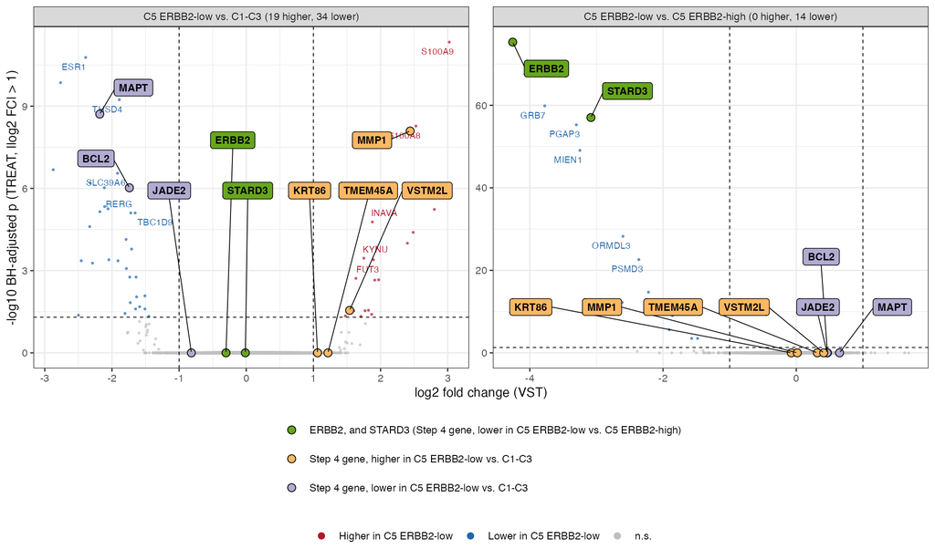

**Figure 9.** Differential expression of C5 ERBB2-low vs. the luminal clusters C1–C3 (left) and vs. C5 ERBB2-high (right): unadjusted limma model, uncorrected VST. y-axis: BH-adjusted TREAT p for |log2 fold change| > 1, so genes with smaller changes sit at the baseline. Red/blue: BH p < 0.05; panel titles give the counts. Small labels: top 5 other genes in each direction by moderated t. Boxed labels: the 8 Step 4 compact-model genes (orange/purple: 7-gene model vs. C1–C3, colored by direction; green: STARD3, 1-gene model vs. C5 ERBB2-high) and ERBB2 (green).

### 5.3 Pathways

**Against the luminal clusters, low ER signalling is the firmest finding** **(Figure 10, Table S28)**.

- **Camera-confirmed in both models:** early estrogen response is lower (unadjusted NES −2.88, BH p < 0.001; camera FDR = 0.009). This is the only program confirmed with and without adjustment.
- **Camera-confirmed only after purity adjustment:** glycolysis (NES +2.69, BH p < 0.001; camera FDR = 0.007) and mTORC1 signalling. Both are rich in epithelial housekeeping genes that a linear purity adjustment can inflate, so they are suggestive, not firm. MYC targets and oxidative phosphorylation, which strengthen only after adjustment, are read the same way.
- **Infiltration:** without adjustment, immune and stromal programs lead (allograft rejection NES +3.40, BH p < 0.001; IFN-γ response, inflammatory response, complement). They pass camera at the default setting only and drop out after adjustment. EMT stays higher after adjustment, but so do fibroblasts (Section 5.4), so it most likely reflects residual stroma.
- **Proliferation and hypoxia:** E2F targets (unadjusted NES +2.04, BH p < 0.001) and hypoxia are higher in both models but pass camera at the default setting only. The comparator is weighted toward luminal A, while this group is mostly luminal B or HER2-enriched by PAM50, so higher proliferation partly reflects that subtype mix.

Together these point to a tumor that expresses ER protein but has a weak ER transcriptional program, with somewhat higher proliferation: features consistent with luminal B or HER2-enriched biology [4].

**Against C5 ERBB2-high, more infiltration and less proliferation, but nothing camera-confirmed.** Unadjusted, immune and EMT programs are higher in C5 ERBB2-low (allograft rejection NES +2.63, BH p < 0.001). In both models, proliferation (G2M checkpoint, adjusted NES −2.86, BH p < 0.001; E2F targets), MYC targets and mTORC1 are lower, passing camera at the default setting only. Lower proliferation fits the absence of amplification, but also the higher share of ER+ tumors.

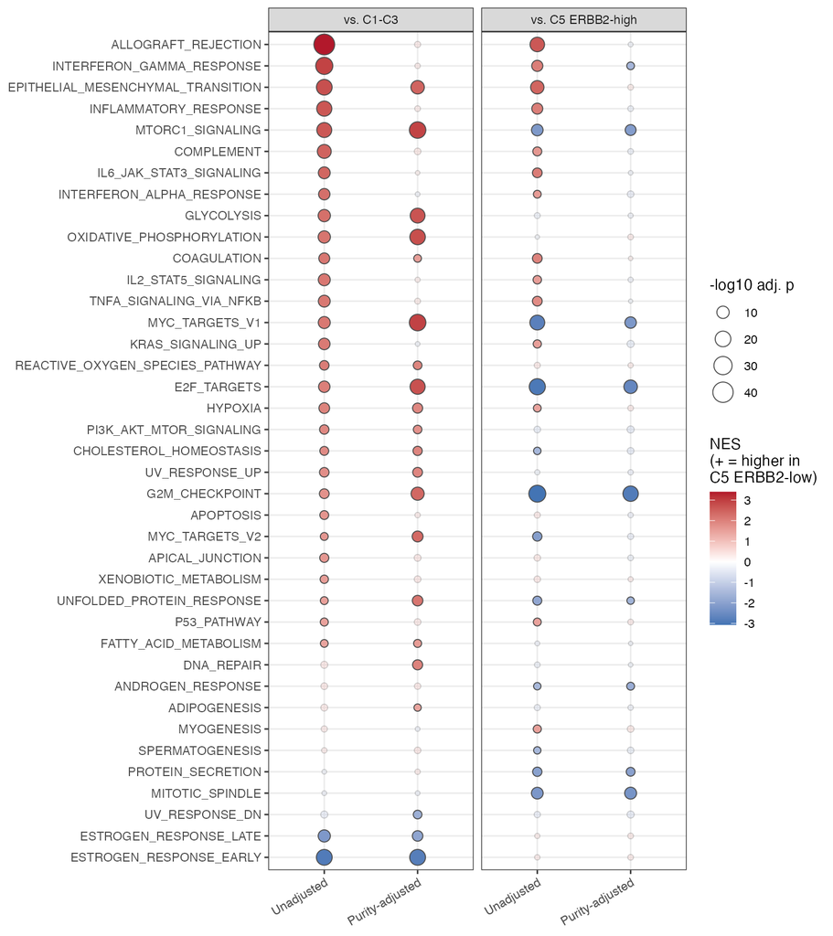

**Figure 10.** Hallmark GSEA (fgsea) of C5 ERBB2-low vs. C1–C3 (left) and vs. C5 ERBB2-high (right), from the unadjusted and the purity-adjusted (ESTIMATE stromal + immune) limma models. Color: NES (red = higher in C5 ERBB2-low). Size: −log10 BH-adjusted p. Faded: not significant (BH p ≥ 0.05). Shown: gene sets significant in at least one model, ordered by NES vs. C1–C3, unadjusted. fgsea p-values ignore inter-gene correlation; see Table S28 for the camera check.

### 5.4 Immune infiltration

**Against the luminal clusters, the group has more of most immune populations and more fibroblasts; relative to the ESTIMATE signal, monocytic-lineage and fibroblast markers are higher** **(Figure 11, Table S29)**.

- **Amount:** T cells (+0.56, BH p < 0.001), CD8 T cells, cytotoxic lymphocytes, B cells, monocytic-lineage (monocyte/macrophage) markers (+0.83, BH p < 0.001) and fibroblasts (+0.63, BH p < 0.001) are all higher; myeloid dendritic cells slightly higher and neutrophils slightly lower.
- **Relative to the ESTIMATE signal:** monocytic-lineage markers (+0.27, BH p < 0.001) and fibroblasts are higher. Endothelial cells, myeloid dendritic cells, B cells and neutrophils are lower, and T cells are in proportion.

**Against C5 ERBB2-high, more of the same infiltrate.** T cells, CD8 T cells, cytotoxic lymphocytes, myeloid dendritic cells and fibroblasts are higher, but no population differs relative to the ESTIMATE signal.

Among the luminal clusters, C2 is also heavily infiltrated, but with more endothelial and fewer monocytic-lineage markers **(Figure 11)**. Lymphocytic infiltration matters differently by subtype: in a pooled analysis of neoadjuvant chemotherapy trials, higher stromal tumor-infiltrating lymphocytes (TILs) in luminal HER2− tumors predicted more pathological complete responses but were linked to shorter overall survival, unlike HER2+ and triple-negative disease [19]. Bulk T-cell scores are only a proxy for TILs.

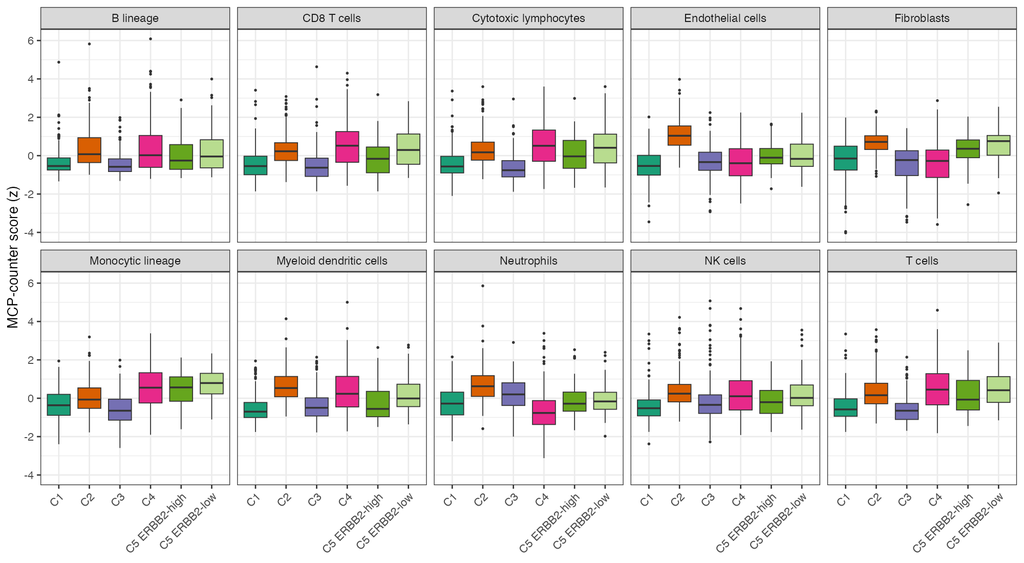

**Figure 11.** MCP-counter immune and stromal cell scores (mean VST of each population’s marker genes, z-scored across primary tumors) by group. Cluster colors as in Figure 7; C5 ERBB2-high in green, C5 ERBB2-low in light green. Scores compare abundance between tumors, not fractions within a tumor.

### 5.5 Comparison with matched normal tissue

**The Step 4 genes shift the same way against matched normal tissue** **(Figure 12)**. Across the 11 pairs, 187 genes are more than two-fold higher and 350 more than two-fold lower in tumor by TREAT. The largest changes are the usual tumor–normal ones: tumor-stroma genes up (MMP11, COL11A1, COL10A1, COMP) and normal breast genes down (LIFR, NDRG2).

- **Step 4 genes:** all 7 compact-model genes move the same way against normal tissue as against luminal tumors **(Table S30)**. Six are significant by the moderated t-test (BH p < 0.05; e.g. MMP1 +4.7, BH p < 0.001, BCL2 −2.1, BH p < 0.001; MAPT only at the margin, BH p = 0.050; KRT86 not), but only MMP1 passes TREAT with 11 pairs. Bulk RNA cannot say whether these changes are in tumor cells or their stroma.
- **Amplicon:** ERBB2 (+0.8, BH p = 0.045) and STARD3 are only slightly above normal tissue, as expected without amplification.
- **Pathways:** proliferation is the strongest tumor program (E2F targets, NES +3.21, BH p < 0.001), with MYC targets, mTORC1, glycolysis, interferon responses and EMT higher, and adipogenesis lower, reflecting fat-rich normal tissue **(Figure S10)**. These pass camera at the default setting; with 11 pairs, none passes the strict setting. TNF-α/NF-κB signalling is lower in tumor, in line with stress and inflammatory responses in adjacent normal tissue [20].
- **Immune and stromal cells:** fibroblasts are higher in tumor, and endothelial cells, NK cells and neutrophils lower **(Table S31)**. T cells, CD8 T cells and B cells show no detectable difference, with wide confidence intervals. Adjacent normal tissue is itself altered and often inflamed, so it is not a clean baseline for immune comparisons.

**Specificity not tested.** Many breast tumors raise MMP1 and lower BCL2 relative to normal tissue, so these changes are not shown to be specific to this group. That would need the same comparison in luminal patients (74 luminal tumors have a matched normal) and a test of the difference between the two changes.

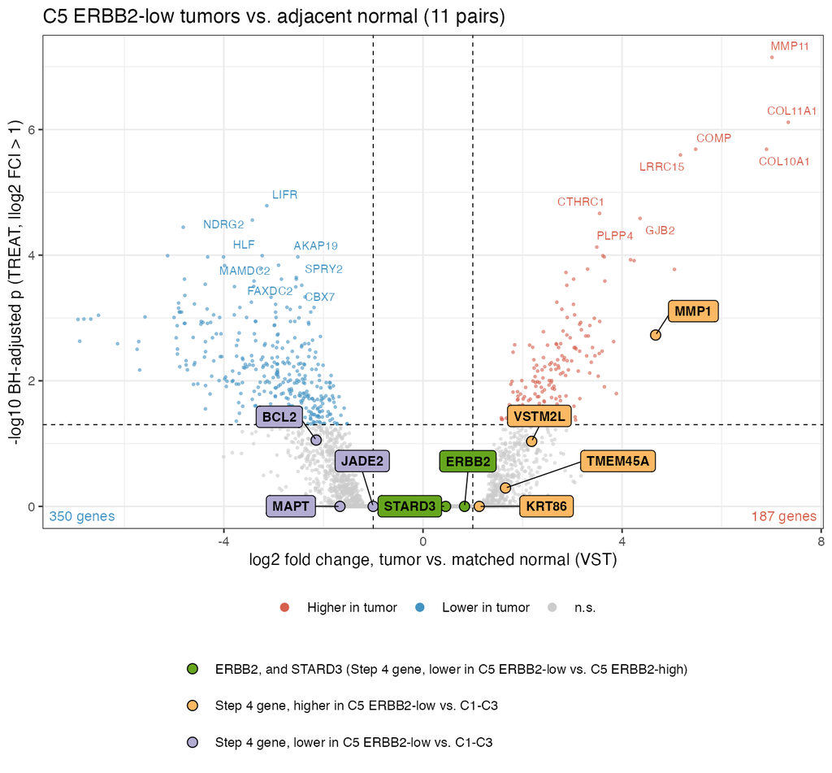

**Figure 12.** Differential expression of the 11 C5 ERBB2-low tumors vs. their matched adjacent normal tissue (paired limma, uncorrected VST). y-axis: BH-adjusted TREAT p for |log2 fold change| > 1. Red/blue: BH p < 0.05. Small labels: top 8 other genes in each direction by moderated t. Boxed labels as in Figure 9.

## 6. Conclusions

**The population.** The C5 ERBB2-low group (83 tumors) is mostly ER+ by IHC yet has a weak ER transcriptional program, its firmest feature. It is heavily infiltrated, with more monocytic-lineage and fibroblast signal than luminal tumors, and leans toward higher proliferation than luminal tumors but lower than amplified tumors. It has no HER2 amplicon and no HER2-specific expression program; 31 of its 34 scored HER2− tumors are HER2-low, a rate likely inflated by how TCGA recorded IHC. HER2-low is common in every cluster, so the group is not unique in ADC eligibility: what sets it apart is its expression state.

**For HER2-directed ADCs (untested here):**

- **Eligibility does not depend on high ERBB2.** Trastuzumab deruxtecan benefits patients with HER2-low [10] and HER2-ultralow [11] disease. Its activity falls with HER2 expression and is lower, but not absent, in HER2-0 tumors [21], and in preclinical models its payload also kills neighbouring HER2-negative cells [22].
- **Bulk ERBB2 mRNA slightly understates HER2 in these tumors.** Infiltrating cells dilute bulk ERBB2 mRNA (after purity adjustment the gap to luminal tumors halves and is no longer significant). This matters only near an mRNA cut-off, and mRNA is not a validated substitute for IHC **(Supplement S6)**.
- **Immune effects are not established in patients.** In one mouse model (colon carcinoma cells engineered to express human HER2), trastuzumab deruxtecan increased antitumor immunity and worked better with anti-PD-1 [23]. Whether an inflamed HER2-low tumor responds differently in patients is not known.

**For endocrine therapy.** The weak ER program suggests these tumors may depend less on estrogen signalling. In metastatic HR+/HER2− disease, PAM50 HER2-enriched tumors (27 of the 83 here, some of them clinically HER2+) were linked, in exploratory retrospective analyses, to benefit from adding lapatinib to letrozole [24], and to a higher risk of progression on endocrine therapy but the largest relative benefit from adding ribociclib (HR 0.39), although benefit was seen in all subtypes except basal-like [25]. These were trials in metastatic disease (for [24], profiled mostly on archival primary tumors), whereas TCGA tumors are untreated primaries.

**Re-testing candidates.** 19 amplified tumors are called HER2− or unresolved **(Table S15)**. They include TCGA-A2-A0YJ-01 and TCGA-A8-A08J-01 (IHC-negative, very high mRNA) and three tumors in the C5 ERBB2-low group (TCGA-C8-A26X-01, TCGA-C8-A138-01, TCGA-C8-A1HL-01).

**Limits.** These are associations in bulk RNA from one cohort, and the tumor–normal changes rest on 11 pairs without a luminal comparison. They do not show what causes the group’s state, which cells express each gene, or whether the group predicts ADC benefit. The next step is validation in an independent cohort with central HER2 IHC and treatment outcomes.

# Supplement

## S1. QC and PC summary

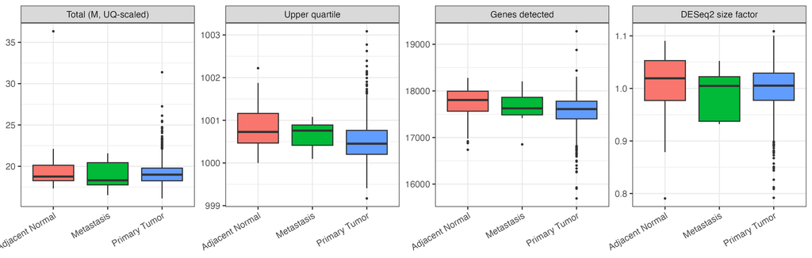

**Figure S1.** Per-sample QC by sample type: UQ-scaled total, upper quartile of non-zero values (~1000 in every sample, confirming UQ scaling), genes detected, and DESeq2 size factor (0.79–1.11).

**Table S1.** Primary-tumor PC1–5: percent variance, best match to PCs from a log2(UQ+1) transform (stability), and the strongest feature associations.

| PC | % variance | \|r\| vs log2(UQ+1) PC | Top features (adj. R²) |
| --- | --- | --- | --- |
| PC1 | 16.6 | 0.99 | ER (0.62); PR (0.45); ERBB2 CN (GISTIC) (0.1) |
| PC2 | 7.9 | 0.92 | Fraction genome altered (0.22); Histology (0.17); Plate (0.06) |
| PC3 | 4.3 | 0.82 | ERBB2 CN (GISTIC) (0.18); Plate (0.14); HER2 IHC (0.13) |
| PC4 | 3.6 | 0.83 | Plate (0.22); Era (0.15); Tissue source site (0.11) |
| PC5 | 3.3 | 0.94 | ERBB2 CN (GISTIC) (0.04); UQ-scaled total (0.04); Tissue source site (0.03) |

## S2. Processing batch

Plate effects are mainly a step between two processing eras at plate A213, which is also where adjacent normals stop being sequenced **(Figure S2)**. The eras differ in more than processing **(Table S2)**:

- **Normals:** 110 of 112 normals are in the earlier era **(Table S3)**.
- **Histology:** the later era is much more often lobular (43% vs. 12%), consistent with TCGA’s expanded lobular cohort [2].
- **ERBB2 amplification:** the apparent drop (13.5% to 6.6%) disappears within ductal tumors, and copy number is missing for 39% of later tumors.
- **Receptors:** ER, PR and HER2 IHC are balanced.

**Table S2.** Sample types and tumor features by processing era. Percentages are among samples with known values; p from Fisher’s exact test (feature vs. rest), unadjusted.

| Feature | Plates before A213 | Plate A213 and after | p |
| --- | --- | --- | --- |
| Adjacent Normal (n) | 110 | 2 |  |
| Metastasis (n) | 3 | 4 |  |
| Primary Tumor (n) | 845 | 248 |  |
| Adjacent normal (% of normal + tumor) | 11.5% | 0.8% | 1.1e-09 |
| Lobular histology | 11.8% | 42.9% | 9.9e-25 |
| ERBB2 copy number missing | 4.3% | 39.1% | 9.3e-41 |
| ERBB2 amplified (GISTIC 2) | 13.5% | 6.6% | 2.1e-02 |
| ERBB2 amplified, ductal only | 14.6% | 13.3% | 1.0e+00 |
| ER positive | 77.2% | 77.4% | 1.0e+00 |
| PR positive | 67.3% | 66.5% | 8.8e-01 |
| HER2 IHC positive | 18.9% | 15.4% | 2.9e-01 |

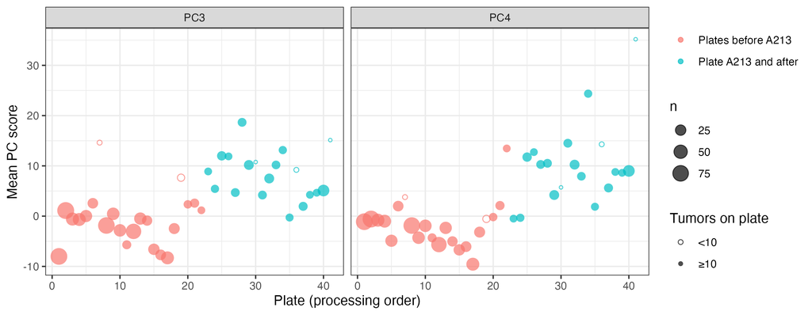

**Figure S2.** Mean primary-tumor PC3 and PC4 scores per plate, in processing order, colored by era. Point size is the number of tumors; open points mark plates with <10 tumors. PC3–4 change with the transform (Table S1), so the shift is read as relative.

All 112 normals sit on 17 plates, two of which hold only normals: A089 (21) and A19E (1) **(Table S3)**. For those 22 normals, plate cannot be separated from normal-tissue biology.

**Table S3.** Samples per sequencing plate in processing order: counts of adjacent normal, primary tumor and metastasis, and each type’s percentage of the plate.

| Plate | Era | Normal | Tumor | Metastasis | Total | % Normal | % Tumor | % Metastasis |
| --- | --- | --- | --- | --- | --- | --- | --- | --- |
| A00Z | Plates before A213 | 0 | 89 | 0 | 89 | 0.0 | 100.0 | 0.0 |
| A034 | Plates before A213 | 0 | 91 | 0 | 91 | 0.0 | 100.0 | 0.0 |
| A056 | Plates before A213 | 0 | 47 | 0 | 47 | 0.0 | 100.0 | 0.0 |
| A084 | Plates before A213 | 0 | 46 | 0 | 46 | 0.0 | 100.0 | 0.0 |
| A089 | Plates before A213 | 21 | 0 | 0 | 21 | 100.0 | 0.0 | 0.0 |
| A109 | Plates before A213 | 0 | 39 | 0 | 39 | 0.0 | 100.0 | 0.0 |
| A10J | Plates before A213 | 0 | 26 | 0 | 26 | 0.0 | 100.0 | 0.0 |
| A10U | Plates before A213 | 0 | 2 | 0 | 2 | 0.0 | 100.0 | 0.0 |
| A115 | Plates before A213 | 5 | 87 | 0 | 92 | 5.4 | 94.6 | 0.0 |
| A12D | Plates before A213 | 16 | 42 | 2 | 60 | 26.7 | 70.0 | 3.3 |
| A12P | Plates before A213 | 15 | 42 | 1 | 58 | 25.9 | 72.4 | 1.7 |
| A137 | Plates before A213 | 7 | 16 | 0 | 23 | 30.4 | 69.6 | 0.0 |
| A13Q | Plates before A213 | 15 | 72 | 0 | 87 | 17.2 | 82.8 | 0.0 |
| A144 | Plates before A213 | 6 | 40 | 0 | 46 | 13.0 | 87.0 | 0.0 |
| A14D | Plates before A213 | 5 | 24 | 0 | 29 | 17.2 | 82.8 | 0.0 |
| A14M | Plates before A213 | 3 | 32 | 0 | 35 | 8.6 | 91.4 | 0.0 |
| A157 | Plates before A213 | 9 | 27 | 0 | 36 | 25.0 | 75.0 | 0.0 |
| A169 | Plates before A213 | 3 | 46 | 0 | 49 | 6.1 | 93.9 | 0.0 |
| A16F | Plates before A213 | 1 | 29 | 0 | 30 | 3.3 | 96.7 | 0.0 |
| A17B | Plates before A213 | 2 | 8 | 0 | 10 | 20.0 | 80.0 | 0.0 |
| A180 | Plates before A213 | 0 | 13 | 0 | 13 | 0.0 | 100.0 | 0.0 |
| A18M | Plates before A213 | 0 | 17 | 0 | 17 | 0.0 | 100.0 | 0.0 |
| A19E | Plates before A213 | 1 | 0 | 0 | 1 | 100.0 | 0.0 | 0.0 |
| A19W | Plates before A213 | 1 | 10 | 0 | 11 | 9.1 | 90.9 | 0.0 |
| A213 | Plate A213 and after | 0 | 10 | 2 | 12 | 0.0 | 83.3 | 16.7 |
| A21T | Plate A213 and after | 1 | 12 | 0 | 13 | 7.7 | 92.3 | 0.0 |
| A22K | Plate A213 and after | 0 | 18 | 0 | 18 | 0.0 | 100.0 | 0.0 |
| A22U | Plate A213 and after | 0 | 10 | 0 | 10 | 0.0 | 100.0 | 0.0 |
| A239 | Plate A213 and after | 0 | 15 | 0 | 15 | 0.0 | 100.0 | 0.0 |
| A24H | Plate A213 and after | 0 | 15 | 1 | 16 | 0.0 | 93.8 | 6.2 |
| A266 | Plate A213 and after | 0 | 21 | 0 | 21 | 0.0 | 100.0 | 0.0 |
| A26B | Plate A213 and after | 0 | 1 | 0 | 1 | 0.0 | 100.0 | 0.0 |
| A27Q | Plate A213 and after | 0 | 15 | 0 | 15 | 0.0 | 100.0 | 0.0 |
| A28M | Plate A213 and after | 0 | 21 | 0 | 21 | 0.0 | 100.0 | 0.0 |
| A29R | Plate A213 and after | 0 | 14 | 0 | 14 | 0.0 | 100.0 | 0.0 |
| A31O | Plate A213 and after | 0 | 12 | 0 | 12 | 0.0 | 100.0 | 0.0 |
| A32P | Plate A213 and after | 0 | 11 | 1 | 12 | 0.0 | 91.7 | 8.3 |
| A32Y | Plate A213 and after | 0 | 2 | 0 | 2 | 0.0 | 100.0 | 0.0 |
| A33J | Plate A213 and after | 0 | 16 | 0 | 16 | 0.0 | 100.0 | 0.0 |
| A352 | Plate A213 and after | 0 | 10 | 0 | 10 | 0.0 | 100.0 | 0.0 |
| A36F | Plate A213 and after | 0 | 10 | 0 | 10 | 0.0 | 100.0 | 0.0 |
| A41B | Plate A213 and after | 0 | 34 | 0 | 34 | 0.0 | 100.0 | 0.0 |
| A466 | Plate A213 and after | 1 | 1 | 0 | 2 | 50.0 | 50.0 | 0.0 |

After accounting for biology, plate still explains 0.09 of PC3 and 0.2 of PC4, over half of it era. The share of normals on a plate explains little **(Table S4)**.

**Table S4.** Adjusted partial R² of each batch term added to a model of the PC on ER, HER2 IHC, histology and fraction genome altered (complete cases). ‘Plate beyond era’ adds plate to a model that already includes era.

| PC | n | Plate % normal | Era | Plate | Plate beyond era |
| --- | --- | --- | --- | --- | --- |
| PC1 | 885 | -0.001 | 0.020 | 0.033 | 0.013 |
| PC2 | 885 | -0.001 | -0.001 | 0.023 | 0.024 |
| PC3 | 885 | 0.003 | 0.052 | 0.087 | 0.038 |
| PC4 | 885 | 0.030 | 0.120 | 0.204 | 0.096 |
| PC5 | 885 | -0.001 | 0.006 | 0.014 | 0.009 |

**Why no correction.**

1. Era is confounded with sample type and histology **(Table S2)**, so correction would remove real biology. Protecting the labels instead would overstate group differences [6].
2. Correction distorts plates holding few tumors **(Supplement S3)**.
3. ER/PR/HER2 signal barely depends on plate **(Figure S3, Figure S4)**.

Replicate-based correction (RUV-III with pseudo-replicates, PRPS) is the principled option for TCGA [5]. If technical replicates run across plates were available, plate correction would be reconsidered.

## S3. Plate correction test (not applied)

Plate was removed from primary-tumor VST with `limma::removeBatchEffect` in three ways:

- **All 41 plates.**
- **Pooled plates:** each plate with <10 tumors was merged into the nearest large plate by processing order.
- **Pooled plates with ER/PR/HER2 protected** in the design.

Plate association after correction is ~0 by construction, so it is not shown. The real check is whether biology survives:

- **ER and PR** associations with PC1 change little **(Figure S3)**.
- **HER2 IHC on PC3** rises slightly (0.13 to 0.14, or 0.16 when protected), so plate partly masked HER2 signal rather than creating it.
- **Marker genes** keep their association with clinical labels, and protecting the labels inflates them, as expected [6] **(Figure S4)**.
- **Small plates:** correcting all 41 plates sets each single-sample plate’s tumor to the cohort mean. For example, the ER− tumor on plate A26B has low ESR1 (6.2 VST); the 41-plate correction replaces it with 11.8, while pooling keeps it at 6.6.

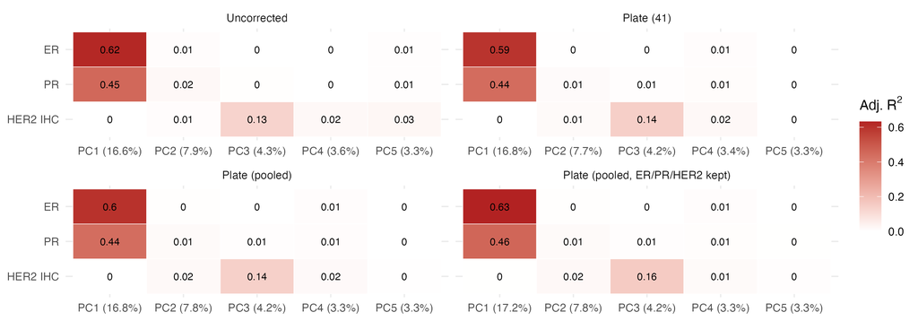

**Figure S3.** Adjusted R² of primary-tumor PC1–5 with ER, PR and HER2 IHC, before and after each plate correction.

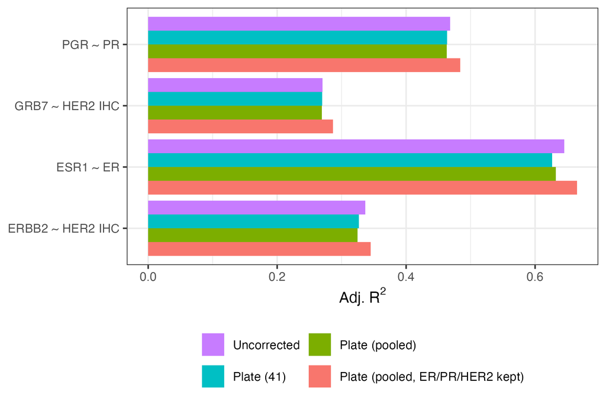

**Figure S4.** Adjusted R² of marker genes (ESR1, PGR, ERBB2, GRB7) with their clinical label, for each plate correction.

## S4. HER2 labels, disagreements and label sources

**Table S5.** Rule that set each tumor’s HER2 status. ‘IHC score’ uses the numeric HER2 IHC score; ‘Reported IHC’ uses the reported IHC status when no score exists; FISH is shown when it informs the call.

| HER2 status | Rule | Tumors |
| --- | --- | --- |
| Conflict | IHC score and reported IHC status disagree | 14 |
| Missing | No IHC or FISH | 117 |
| Negative | IHC score 0/1+ | 223 |
| Negative | Reported IHC Negative | 211 |
| Negative | IHC score 2+, FISH Negative | 138 |
| Negative | IHC score 0/1+, FISH Negative | 94 |
| Negative | FISH only: Negative | 57 |
| Negative | Reported IHC Negative, FISH Negative | 31 |
| Negative | Reported IHC Equivocal, FISH Negative | 5 |
| Positive | IHC score 3+ | 60 |
| Positive | IHC score 2+, FISH Positive | 36 |
| Positive | Reported IHC Positive | 31 |
| Positive | IHC score 3+, FISH Positive | 23 |
| Positive | FISH only: Positive | 9 |
| Positive | Reported IHC Positive, FISH Positive | 7 |
| Positive | IHC score 3+, FISH Negative | 4 |
| Unresolved | IHC score 2+ | 25 |
| Unresolved | IHC score 0/1+, FISH Positive | 3 |
| Unresolved | Reported IHC Positive, FISH Negative | 3 |
| Unresolved | Reported IHC Equivocal | 2 |

**Table S6.** Disagreements between HER2 sources, with the status each tumor received (columns). IHC score vs. reported IHC status lists only pairs that give different calls. The bottom rows compare final status with ERBB2 amplification (GISTIC), by label source.

| Disagreement | Positive | Negative | Unresolved | Conflict | Total |
| --- | --- | --- | --- | --- | --- |
| HER2+ (FISH only) vs not amplified (GISTIC < 2) | 4 | 0 | 0 | 0 | 4 |
| HER2+ (Numeric IHC score) vs not amplified (GISTIC < 2) | 37 | 0 | 0 | 0 | 37 |
| HER2+ (Reported IHC status only) vs not amplified (GISTIC < 2) | 20 | 0 | 0 | 0 | 20 |
| HER2- (FISH only) vs amplified (GISTIC 2) | 0 | 1 | 0 | 0 | 1 |
| HER2- (Numeric IHC score) vs amplified (GISTIC 2) | 0 | 11 | 0 | 0 | 11 |
| IHC 0/1+ or reported Negative vs FISH Positive | 0 | 0 | 3 | 0 | 3 |
| IHC 3+ or reported Positive vs FISH Negative | 4 | 0 | 3 | 1 | 8 |
| IHC score 1+ vs reported IHC Positive | 0 | 0 | 0 | 11 | 11 |
| IHC score 2+ vs reported IHC Positive | 0 | 0 | 6 | 0 | 6 |
| IHC score 2+ vs reported IHC Positive, FISH Negative | 0 | 6 | 0 | 0 | 6 |
| IHC score 3+ vs reported IHC Equivocal, FISH Negative | 0 | 0 | 0 | 1 | 1 |
| IHC score 3+ vs reported IHC Negative | 0 | 0 | 0 | 2 | 2 |

**Non-amplified HER2+ tumors.** Of the 61 non-amplified HER2+ tumors with copy-number data, 19 are IHC 2+/FISH+ (12 with a low-level gain). Under 2018 rules, those in ISH groups 2 and 4 would be negative, which cannot be checked here. Low purity could hide amplification. Purity was estimated from RNA-seq as the ESTIMATE score (stromal plus immune signal; higher = lower purity; range −4,141 to 4,105 in this cohort). Among HER2+ tumors with a numeric IHC score, amplified tumors have a median of −6 (IQR −996 to 960) and non-amplified tumors −218 (IQR −819 to 387) (Wilcoxon rank-sum p = 0.32), so there is no evidence that low purity explains the gap.

**Label noise by source.** Raw ERBB2 mRNA and copy number were scored against the IHC label by AUC (DeLong 95% CI), separately by label source **(Table S7)**. The reported-only positives come mostly from sites BH and E9 **(Table S8)**. Reported-only tumors are slightly more often from the later era (20% vs. 12%) and lobular (21% vs. 15%), too little to explain the AUC gap. One example: TCGA-E9-A1NC-01 is reported Positive with no score or FISH, yet has an ERBB2 copy loss and low mRNA.

**Table S7.** Raw ERBB2 mRNA and ERBB2 copy number (GISTIC) vs. IHC 3+ (positive) or 0/1+ (negative), by label source: numeric IHC score, or reported IHC status only. All sites, and excluding sites BH and E9 (chosen after inspection). AUC (no model) with DeLong 95% CI. All tumors with copy-number data, so counts differ slightly from Table 2, which also requires complete ER, PR, histology and purity.

| Sites | Label source | Predictor | Tumors | IHC positive | AUC (95% CI) |
| --- | --- | --- | --- | --- | --- |
| All sites | Numeric IHC score | ERBB2 mRNA | 368 | 77 | 0.928 (0.888–0.967) |
| All sites | Numeric IHC score | ERBB2 GISTIC | 368 | 77 | 0.895 (0.847–0.943) |
| All sites | Reported IHC status only | ERBB2 mRNA | 240 | 31 | 0.643 (0.524–0.762) |
| All sites | Reported IHC status only | ERBB2 GISTIC | 240 | 31 | 0.597 (0.467–0.727) |
| Excluding sites BH, E9 | Numeric IHC score | ERBB2 mRNA | 333 | 71 | 0.921 (0.878–0.964) |
| Excluding sites BH, E9 | Numeric IHC score | ERBB2 GISTIC | 333 | 71 | 0.885 (0.834–0.937) |
| Excluding sites BH, E9 | Reported IHC status only | ERBB2 mRNA | 149 | 8 | 0.850 (0.697–1.000) |
| Excluding sites BH, E9 | Reported IHC status only | ERBB2 GISTIC | 149 | 8 | 0.790 (0.581–0.999) |

**Table S8.** Tissue source sites with reported-only IHC-positive tumors: tumors with a numeric IHC score, tumors with only a reported IHC status, and reported-only positives (and how many are ERBB2-amplified). Tumors with copy-number data and an IHC 3+ vs. 0/1+ label only.

| Site | Scored tumors | Reported-only tumors | Reported-only positive | … of which amplified |
| --- | --- | --- | --- | --- |
| BH | 34 | 68 | 12 | 6 |
| E9 | 1 | 23 | 11 | 1 |
| AC | 4 | 16 | 4 | 2 |
| PE | 0 | 3 | 2 | 0 |
| A1 | 4 | 7 | 1 | 1 |
| A2 | 49 | 15 | 1 | 1 |

## S5. Clinical variables and HER2 status

Each clinical variable was tested for association with the main IHC target (numeric score, 3+ vs. 0/1+) in a univariable logistic model, then added to the RNA + DNA model (Section 2.3). Each test was a likelihood-ratio test, with BH adjustment within each set **(Table S9)**. Five interaction models (two variables plus their product) were tested the same way, for the interaction term **(Table S10)**.

- **Alone:** only PR survives adjustment (PR− tumors are more often HER2+).
- **Race:** Asian patients are more often HER2+ than White patients (OR 3.2, Wald p = 0.007), but race as a whole does not survive adjustment (likelihood-ratio p = 0.03, BH-adjusted 0.07). White is the reference; one American Indian patient was excluded as too rare, and race is missing for 65 tumors.
- **Added to mRNA and copy number:** no clinical variable adds anything, and no interaction is significant.
- **Sex:** only 6 males (2 HER2+), too few to assess. **Histology:** lobular vs. all other types.

A molecular + clinical model (ERBB2 mRNA + GISTIC + ER + PR + age + race) was fitted on the 303 tumors with complete data. Its CV AUC matches the molecular model on the same tumors **(Table S12, Table S13)**.

| Variable | Tumors | HER2+ | OR (95% CI) | p alone (adj.) | p added to RNA + DNA (adj.) |
| --- | --- | --- | --- | --- | --- |
| Age (per 10 y) | 407 | 87 | 1.00 (0.83–1.20) | 0.975 | 0.462 |
| Sex | 407 | 87 | Male 1.86 (0.25–9.69) | 0.824 | 0.728 |
| Race | 342 | 70 | Black or african american 1.38 (0.65–2.76); Asian 3.16 (1.35–7.20) | 0.068 | 0.728 |
| ER | 406 | 86 | Positive 0.53 (0.32–0.90) | 0.067 | 0.728 |
| PR | 406 | 87 | Positive 0.48 (0.29–0.77) | 0.020 | 0.728 |
| Histology | 407 | 87 | Lobular 0.93 (0.46–1.75) | 0.957 | 0.728 |
| Era | 407 | 87 | Plates before a213 0.84 (0.46–1.60) | 0.824 | 0.462 |

**Table S10.** Interaction models for HER2 IHC status: likelihood-ratio test of the interaction term against main effects only, BH-adjusted.

| Interaction | Tumors | p | p (adj.) |
| --- | --- | --- | --- |
| ER x PR | 405 | 0.948 | 0.964 |
| Age x ER | 406 | 0.509 | 0.849 |
| Race x ER | 341 | 0.127 | 0.548 |
| ERBB2 mRNA x ER | 406 | 0.219 | 0.548 |
| ERBB2 mRNA x Race | 342 | 0.964 | 0.964 |

## S6. RNA vs. DNA: detailed results and caveats

**RNA vs. DNA by target.** Raw-value AUCs are compared by paired DeLong test **(Table 2)**. CV results use the logistic models and corrected repeated k-fold t-test described in **(Supplement S7)**.

- **Main target (366 tumors, 76 IHC 3+):**
  - **Primary test:** the raw AUC is 0.927 for mRNA vs. 0.893 for copy number (difference 0.033, 95% CI 0.001–0.066, paired DeLong p = 0.045).
  - **CV:** the logistic models agree in direction (5-fold: 0.927 vs. 0.889, corrected t-test p = 0.03, BH-adjusted 0.18; final 10-fold: 0.927 vs. 0.890, p = 0.05) **(Figure 5)**.
  - The evidence is modest.
- **Other HER2 targets:**
  - **Reported status included:** RNA leads but not significantly (raw p = 0.06).
  - **FISH-resolved clinical status:** RNA leads on raw values (p = 0.04), but CV shows no difference (+0.009, corrected t-test p = 0.67, BH-adjusted 0.93).
- **By processing era:** RNA leads in both eras, but neither difference is significant on its own (the later era has only 8 positives).
- **HER2-low:** RNA is clearly better.
  - **HER2-low vs. HER2-0:** 0.685 vs. 0.573, p = 0.001. This group mixes IHC 1+ with 2+/FISH− tumors, which have higher mRNA **(Figure 3)**.
  - **IHC 1+ vs. 0 (the harder clinical split):** RNA still leads (0.652 vs. 0.554, p = 0.008; CV BH-adjusted p = 0.03).
  - **Model:** the RNA logistic model with HER2-low as the outcome gives $\beta_1$ = 0.81 **(Table S11)**.
  - **Not just ER biology:** HER2-low is enriched in HR+ disease [16], so RNA could be riding on ER biology. It still leads within ER+ tumors (0.655 vs. 0.559, p = 0.04) and in CV models that include ER (+0.13, BH-adjusted p = 0.03).
  - **Ceiling:** pathologists agree poorly on IHC 0 vs. 1+ [26], which caps any predictor of this split.
  - **Ultralow:** TCGA “IHC 0” probably includes HER2-ultralow tumors (faint staining below 1+). These are now also eligible for trastuzumab deruxtecan in HR+ disease [11], so for HR+ tumors the treatment decision now lies below IHC 0 vs. 1+.

**Combining predictors.** In CV logistic models **(Table S12, Table S13)**, each step below leaves the AUC not significantly changed (all BH-adjusted p ≥ 0.22):

- **Copy number** added to mRNA (the RNA + DNA model).
- **ER and PR** added to RNA + DNA (the molecular model).
- **The 17q12 co-amplified genes** GRB7, STARD3 and PGAP3 added to the molecular model. They track ERBB2 closely, so add little independent information; the only trend is with the noisy reported-status target (+0.027, corrected t-test p = 0.06, BH-adjusted 0.22).
- **Tumor purity** (ESTIMATE, with interaction) added to mRNA or to copy number.
- **Era and histology** added to mRNA or to copy number.

**Caveats.**

- **The label matters.** The main label is IHC, a protein readout, which an mRNA measure tracks more directly than copy number. The FISH-resolved clinical status partly favors copy number instead, and there DNA does not beat RNA either. FISH itself could not be a predictor without leaking the label.
- **The scales differ.** mRNA is continuous, while GISTIC has five levels.
- **mRNA is not a validated substitute.** A commercial ERBB2 mRNA assay (Oncotype DX) missed some IHC/FISH-positive tumors [27], so mRNA alone is not a validated substitute for IHC/FISH.

## S7. Logistic models and cross-validation

**Models.** All models are logistic regressions that extend the RNA, DNA and RNA + DNA models of Section 2.3. Two models are specific enough to write out. The molecular model, which also produces the discordance calls in Table S14, is

$$\textbf{Molecular:}\quad
\operatorname{logit} P = \beta_0 + \beta_1\,\text{ERBB2} +
\textstyle\sum_{c} \gamma_c\,[\text{CN}=c] +
\beta_{\text{ER}}\,\text{ER} + \beta_{\text{PR}}\,\text{PR}$$

with ER and PR coded positive = 1. The purity models add a main effect and an interaction:

$$\textbf{RNA} \times
\textbf{purity:}\quad \operatorname{logit} P = \beta_0 +
\beta_1\,\text{ERBB2} + \delta\,\text{Purity} + \theta\,\text{ERBB2}
\times \text{Purity}$$

Purity is the ESTIMATE score divided by 1,000. The DNA × purity model is the same, with the copy-number indicators in place of ERBB2. The other models add covariates as main effects:

- **17q12:** GRB7, STARD3 and PGAP3 mRNA, added to the molecular model.
- **Era and histology.**
- **Age and race.**

GISTIC −2 (n = 1) is merged into the −1 reference. Coefficients fitted on the full data are in **(Table S11)**.

**Cross-validation.** Stratified k-fold CV over 10 repeats (5 folds for exploration, 10 for the selected model). Every model in an analysis uses the same tumors and folds.

- **AUC:** computed within each test fold and then averaged. Pooling out-of-fold predictions across folds biases AUC downward, most for the discrete GISTIC predictor.
- **Comparisons:** paired comparisons and confidence intervals use the corrected repeated k-fold t-test, which accounts for overlapping training sets. p values are BH-adjusted across the 22 exploration comparisons. The final 10-fold run repeats main-target tests, so its p values are left unadjusted.

All results are shown in **(Figure S5)**.

**Table S11.** Logistic regression coefficients (log-odds) fitted on all tumors of the main target (IHC score 3+ vs. 0/1+) or HER2-low vs. HER2-0. ERBB2: mRNA (VST); GISTIC c: indicator for copy-number level c (reference −1/−2); ER/PR: positive vs. negative. Wald p values.

| Model | Term | β (95% CI) | p | Tumors |
| --- | --- | --- | --- | --- |
| RNA | (Intercept) | -24.05 (-30.15 to -19.24) | <0.001 | 366 |
| RNA | ERBB2 | 1.66 (1.31 to 2.11) | <0.001 | 366 |
| DNA | (Intercept) | -3.31 (-4.71 to -2.33) | <0.001 | 366 |
| DNA | GISTIC0 | 0.45 (-0.83 to 1.99) | 0.519 | 366 |
| DNA | GISTIC1 | 1.16 (-0.16 to 2.73) | 0.103 | 366 |
| DNA | GISTIC2 | 5.29 (4.06 to 6.86) | <0.001 | 366 |
| RNA + DNA | (Intercept) | -21.72 (-30.72 to -14.38) | <0.001 | 366 |
| RNA + DNA | ERBB2 | 1.50 (0.92 to 2.22) | <0.001 | 366 |
| RNA + DNA | GISTIC0 | -0.47 (-1.83 to 1.12) | 0.517 | 366 |
| RNA + DNA | GISTIC1 | -0.38 (-1.92 to 1.32) | 0.638 | 366 |
| RNA + DNA | GISTIC2 | 0.28 (-2.14 to 2.61) | 0.813 | 366 |
| Molecular (RNA + DNA + ER + PR) | (Intercept) | -21.98 (-31.03 to -14.55) | <0.001 | 366 |
| Molecular (RNA + DNA + ER + PR) | ERBB2 | 1.51 (0.92 to 2.23) | <0.001 | 366 |
| Molecular (RNA + DNA + ER + PR) | GISTIC0 | -0.52 (-1.90 to 1.08) | 0.476 | 366 |
| Molecular (RNA + DNA + ER + PR) | GISTIC1 | -0.45 (-2.02 to 1.27) | 0.581 | 366 |
| Molecular (RNA + DNA + ER + PR) | GISTIC2 | 0.30 (-2.16 to 2.65) | 0.804 | 366 |
| Molecular (RNA + DNA + ER + PR) | ERPositive | 0.04 (-1.71 to 1.88) | 0.962 | 366 |
| Molecular (RNA + DNA + ER + PR) | PRPositive | 0.25 (-1.10 to 1.82) | 0.732 | 366 |
| HER2-low: RNA | (Intercept) | -8.42 (-13.17 to -3.92) | <0.001 | 406 |
| HER2-low: RNA | ERBB2 | 0.81 (0.45 to 1.20) | <0.001 | 406 |
| HER2-low: DNA | (Intercept) | 1.28 (0.82 to 1.77) | <0.001 | 406 |
| HER2-low: DNA | GISTIC0 | 0.64 (0.01 to 1.27) | 0.045 | 406 |
| HER2-low: DNA | GISTIC1 | 0.81 (0.03 to 1.66) | 0.049 | 406 |
| HER2-low: DNA | GISTIC2 | 0.23 (-1.22 to 2.15) | 0.783 | 406 |

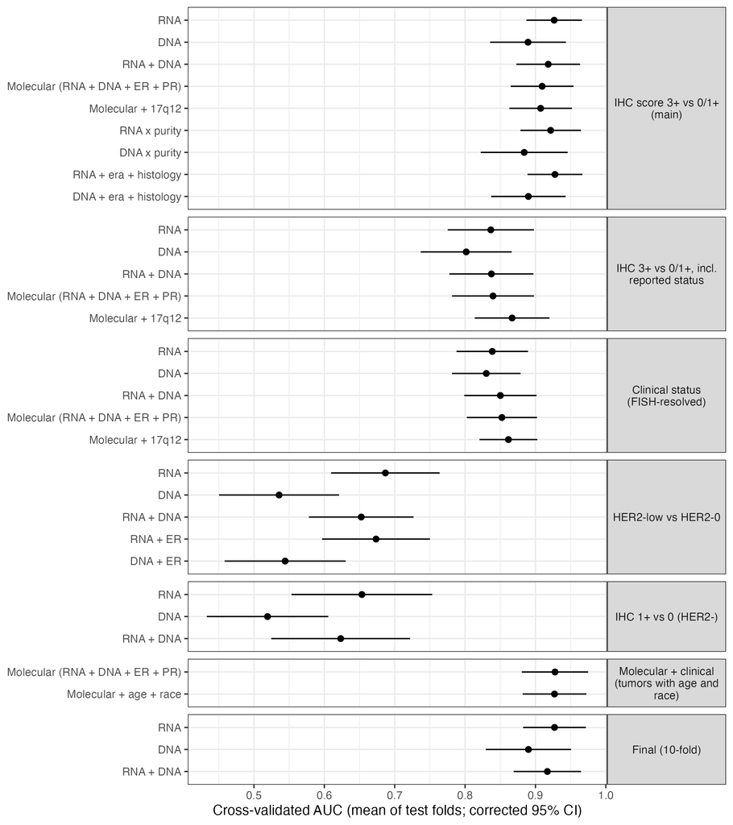

**Figure S5.** Cross-validated AUC (mean over test folds and repeats, with corrected 95% CI) for every logistic model and target. Molecular: ERBB2 mRNA + GISTIC + ER + PR; 17q12: GRB7, STARD3, PGAP3 mRNA; purity: ESTIMATE score (with interaction).

**Table S12.** Cross-validated AUC of each logistic model (mean over test folds and repeats; corrected 95% CI) (Figure S5).

| Analysis | Model | Tumors | Positive | Folds | CV AUC (95% CI) |
| --- | --- | --- | --- | --- | --- |
| IHC score 3+ vs 0/1+ (main) | RNA | 366 | 76 | 5 | 0.927 (0.887–0.966) |
| IHC score 3+ vs 0/1+ (main) | DNA | 366 | 76 | 5 | 0.889 (0.836–0.943) |
| IHC score 3+ vs 0/1+ (main) | RNA + DNA | 366 | 76 | 5 | 0.918 (0.873–0.963) |
| IHC score 3+ vs 0/1+ (main) | Molecular (RNA + DNA + ER + PR) | 366 | 76 | 5 | 0.909 (0.865–0.954) |
| IHC score 3+ vs 0/1+ (main) | Molecular + 17q12 | 366 | 76 | 5 | 0.907 (0.863–0.952) |
| IHC score 3+ vs 0/1+ (main) | RNA x purity | 366 | 76 | 5 | 0.922 (0.879–0.965) |
| IHC score 3+ vs 0/1+ (main) | DNA x purity | 366 | 76 | 5 | 0.884 (0.822–0.946) |
| IHC score 3+ vs 0/1+ (main) | RNA + era + histology | 366 | 76 | 5 | 0.928 (0.889–0.967) |
| IHC score 3+ vs 0/1+ (main) | DNA + era + histology | 366 | 76 | 5 | 0.890 (0.837–0.943) |
| IHC 3+ vs 0/1+, incl. reported status | RNA | 603 | 107 | 5 | 0.837 (0.775–0.898) |
| IHC 3+ vs 0/1+, incl. reported status | DNA | 603 | 107 | 5 | 0.802 (0.737–0.866) |
| IHC 3+ vs 0/1+, incl. reported status | RNA + DNA | 603 | 107 | 5 | 0.837 (0.778–0.897) |
| IHC 3+ vs 0/1+, incl. reported status | Molecular (RNA + DNA + ER + PR) | 603 | 107 | 5 | 0.840 (0.781–0.898) |
| IHC 3+ vs 0/1+, incl. reported status | Molecular + 17q12 | 603 | 107 | 5 | 0.867 (0.814–0.920) |
| Clinical status (FISH-resolved) | RNA | 814 | 150 | 5 | 0.839 (0.788–0.890) |
| Clinical status (FISH-resolved) | DNA | 814 | 150 | 5 | 0.830 (0.781–0.879) |
| Clinical status (FISH-resolved) | RNA + DNA | 814 | 150 | 5 | 0.850 (0.799–0.901) |
| Clinical status (FISH-resolved) | Molecular (RNA + DNA + ER + PR) | 814 | 150 | 5 | 0.852 (0.802–0.902) |
| Clinical status (FISH-resolved) | Molecular + 17q12 | 814 | 150 | 5 | 0.862 (0.821–0.903) |
| HER2-low vs HER2-0 | RNA | 406 | 346 | 5 | 0.687 (0.610–0.764) |
| HER2-low vs HER2-0 | DNA | 406 | 346 | 5 | 0.536 (0.450–0.621) |
| HER2-low vs HER2-0 | RNA + DNA | 406 | 346 | 5 | 0.652 (0.578–0.727) |
| HER2-low vs HER2-0 | RNA + ER | 406 | 346 | 5 | 0.673 (0.597–0.750) |
| HER2-low vs HER2-0 | DNA + ER | 406 | 346 | 5 | 0.544 (0.458–0.630) |
| IHC 1+ vs 0 (HER2-) | RNA | 287 | 227 | 5 | 0.653 (0.553–0.753) |
| IHC 1+ vs 0 (HER2-) | DNA | 287 | 227 | 5 | 0.519 (0.433–0.606) |
| IHC 1+ vs 0 (HER2-) | RNA + DNA | 287 | 227 | 5 | 0.623 (0.525–0.722) |
| Molecular + clinical (tumors with age and race) | Molecular (RNA + DNA + ER + PR) | 303 | 59 | 5 | 0.928 (0.881–0.975) |
| Molecular + clinical (tumors with age and race) | Molecular + age + race | 303 | 59 | 5 | 0.927 (0.882–0.972) |
| Final (10-fold) | RNA | 366 | 76 | 10 | 0.927 (0.882–0.972) |
| Final (10-fold) | DNA | 366 | 76 | 10 | 0.890 (0.830–0.951) |
| Final (10-fold) | RNA + DNA | 366 | 76 | 10 | 0.917 (0.869–0.965) |

**Table S13.** Paired model comparisons (first model minus second): mean AUC difference over test folds and repeats, with corrected repeated k-fold t-test CI and p, BH-adjusted across all comparisons.

| Analysis | Comparison | AUC difference (95% CI) | p | p (BH) |
| --- | --- | --- | --- | --- |
| IHC score 3+ vs 0/1+ (main) | RNA vs DNA | 0.037 (0.003 to 0.071) | 0.033 | 0.184 |
| IHC score 3+ vs 0/1+ (main) | RNA + DNA vs RNA | -0.008 (-0.019 to 0.003) | 0.127 | 0.330 |
| IHC score 3+ vs 0/1+ (main) | Molecular (RNA + DNA + ER + PR) vs RNA + DNA | -0.009 (-0.022 to 0.005) | 0.211 | 0.421 |
| IHC score 3+ vs 0/1+ (main) | Molecular + 17q12 vs Molecular (RNA + DNA + ER + PR) | -0.002 (-0.016 to 0.012) | 0.765 | 0.931 |
| IHC score 3+ vs 0/1+ (main) | RNA x purity vs RNA | -0.005 (-0.023 to 0.013) | 0.574 | 0.931 |
| IHC score 3+ vs 0/1+ (main) | DNA x purity vs DNA | -0.005 (-0.033 to 0.022) | 0.692 | 0.931 |
| IHC score 3+ vs 0/1+ (main) | RNA + era + histology vs RNA | 0.001 (-0.006 to 0.009) | 0.769 | 0.931 |
| IHC score 3+ vs 0/1+ (main) | DNA + era + histology vs DNA | 0.000 (-0.023 to 0.024) | 0.969 | 0.969 |
| IHC 3+ vs 0/1+, incl. reported status | RNA vs DNA | 0.035 (-0.011 to 0.081) | 0.135 | 0.330 |
| IHC 3+ vs 0/1+, incl. reported status | RNA + DNA vs RNA | 0.001 (-0.020 to 0.022) | 0.938 | 0.969 |
| IHC 3+ vs 0/1+, incl. reported status | Molecular (RNA + DNA + ER + PR) vs RNA + DNA | 0.002 (-0.016 to 0.021) | 0.804 | 0.931 |
| IHC 3+ vs 0/1+, incl. reported status | Molecular + 17q12 vs Molecular (RNA + DNA + ER + PR) | 0.027 (-0.001 to 0.055) | 0.058 | 0.222 |
| Clinical status (FISH-resolved) | RNA vs DNA | 0.009 (-0.031 to 0.048) | 0.667 | 0.931 |
| Clinical status (FISH-resolved) | RNA + DNA vs RNA | 0.011 (-0.005 to 0.028) | 0.162 | 0.356 |
| Clinical status (FISH-resolved) | Molecular (RNA + DNA + ER + PR) vs RNA + DNA | 0.002 (-0.006 to 0.011) | 0.603 | 0.931 |
| Clinical status (FISH-resolved) | Molecular + 17q12 vs Molecular (RNA + DNA + ER + PR) | 0.009 (-0.008 to 0.027) | 0.293 | 0.537 |
| HER2-low vs HER2-0 | RNA vs DNA | 0.151 (0.050 to 0.252) | 0.004 | 0.032 |
| HER2-low vs HER2-0 | RNA + DNA vs RNA | -0.034 (-0.070 to 0.002) | 0.060 | 0.222 |
| HER2-low vs HER2-0 | RNA + ER vs DNA + ER | 0.129 (0.049 to 0.210) | 0.002 | 0.025 |
| IHC 1+ vs 0 (HER2-) | RNA vs DNA | 0.134 (0.052 to 0.216) | 0.002 | 0.025 |
| IHC 1+ vs 0 (HER2-) | RNA + DNA vs RNA | -0.030 (-0.068 to 0.008) | 0.117 | 0.330 |
| Molecular + clinical (tumors with age and race) | Molecular + age + race vs Molecular (RNA + DNA + ER + PR) | -0.001 (-0.015 to 0.014) | 0.920 | 0.969 |
| Final (10-fold) | RNA vs DNA | 0.037 (-0.000 to 0.074) | 0.051 | NA |
| Final (10-fold) | RNA + DNA vs RNA | -0.010 (-0.020 to 0.000) | 0.053 | NA |

## S8. Discordant tumors and re-testing candidates

**Molecular model vs. IHC** **(Table S14)**. Of the 18 strongly discordant scored tumors:

- **IHC-negative, amplified with very high mRNA (2):** TCGA-A2-A0YJ-01 (IHC 0) and TCGA-A8-A08J-01 (IHC 1+, FISH−). Across the cohort, 12 HER2− tumors are amplified.
- **Site A8 (6 of 16 IHC 3+):** all FISH+, with GISTIC loss, no change or a low-level gain. Across site A8, 7 of 14 IHC 3+/FISH+ tumors look like this. FISH amplification without a copy-number or mRNA signal is hard to explain biologically, and together with A8-A08J this points to site-level annotation problems.
- **Lobular (4 of 16 IHC 3+):** all from the later era. Two of them, plus A2-A0EQ, are FISH−, which points to IHC over-scoring. ERBB2 activating mutations occur in about 5% of lobular cancers [28]; they switch on HER2 signalling without overexpression, so are unlikely to produce IHC 3+ (mutation data are not available here).

**Table S14.** Scored tumors where the molecular logistic model (ERBB2 mRNA + GISTIC + ER + PR) strongly disagrees with IHC: IHC 3+ with predicted probability <0.2, or IHC 0/1+ with >0.8. Probability: out-of-fold prediction (5-fold CV) averaged over 10 repeats. ESTIMATE: higher = lower purity.

| Sample | Site | IHC score | Reported IHC | FISH | ERBB2 mRNA | GISTIC | ER | PR | Histology | Era | ESTIMATE | P(HER2+) |
| --- | --- | --- | --- | --- | --- | --- | --- | --- | --- | --- | --- | --- |
| TCGA-A8-A08H-01 | A8 | 3+ | Positive | Positive | 11.2 | 0 | Positive | Positive | Non-lobular | Plates before A213 | 3243 | 0.0027 |
| TCGA-A2-A0EQ-01 | A2 | 3+ | Positive | Negative | 12.6 | 0 | Negative | Negative | Non-lobular | Plates before A213 | 1122 | 0.0170 |
| TCGA-AN-A0AJ-01 | AN | 3+ | Positive | NA | 12.5 | 0 | Positive | Positive | Non-lobular | Plates before A213 | 100 | 0.0270 |
| TCGA-A8-A09N-01 | A8 | 3+ | Positive | Positive | 12.3 | -1 | Positive | Positive | Non-lobular | Plates before A213 | -913 | 0.0300 |
| TCGA-A7-A425-01 | A7 | 3+ | NA | Negative | 12.7 | 0 | Positive | Positive | Lobular | Plate A213 and after | 346 | 0.0350 |
| TCGA-AR-A255-01 | AR | 3+ | Positive | NA | 12.8 | 1 | Positive | Positive | Non-lobular | Plates before A213 | 652 | 0.0470 |
| TCGA-JL-A3YX-01 | JL | 3+ | Positive | NA | 12.8 | 0 | Positive | Positive | Lobular | Plate A213 and after | -1753 | 0.0530 |
| TCGA-AQ-A04L-01 | AQ | 3+ | Positive | NA | 13.0 | -1 | Positive | Negative | Non-lobular | Plates before A213 | -711 | 0.0580 |
| TCGA-A8-A08G-01 | A8 | 3+ | Positive | Positive | 13.1 | 1 | Positive | Positive | Non-lobular | Plates before A213 | -533 | 0.0620 |
| TCGA-A8-A06X-01 | A8 | 3+ | Positive | Positive | 13.0 | -1 | Positive | Negative | Non-lobular | Plates before A213 | -685 | 0.0620 |
| TCGA-AR-A5QN-01 | AR | 3+ | Positive | NA | 13.1 | 0 | Positive | Positive | Lobular | Plate A213 and after | -81 | 0.0700 |
| TCGA-D8-A1XY-01 | D8 | 3+ | Positive | NA | 13.1 | 1 | Positive | Positive | Non-lobular | Plates before A213 | -70 | 0.0740 |
| TCGA-LL-A5YL-01 | LL | 3+ | Positive | Negative | 13.6 | 0 | Positive | Negative | Lobular | Plate A213 and after | 14 | 0.0760 |
| TCGA-A8-A099-01 | A8 | 3+ | Positive | Positive | 13.4 | 0 | Positive | Positive | Non-lobular | Plates before A213 | -819 | 0.0970 |
| TCGA-D8-A1XS-01 | D8 | 3+ | Positive | NA | 13.6 | 1 | Positive | Positive | Non-lobular | Plates before A213 | -218 | 0.1400 |
| TCGA-A8-A08P-01 | A8 | 3+ | Positive | Positive | 13.5 | 1 | Positive | Positive | Non-lobular | Plates before A213 | 1339 | 0.1500 |
| TCGA-A8-A08J-01 | A8 | 1+ | Negative | Negative | 16.9 | 2 | Positive | Negative | Non-lobular | Plates before A213 | -296 | 0.9900 |
| TCGA-A2-A0YJ-01 | A2 | 0 | Negative | NA | 15.7 | 2 | Positive | Negative | Non-lobular | Plates before A213 | -2298 | 0.9200 |

**Amplified tumors called HER2− or unresolved** **(Table S15)**. 19 tumors are amplified (GISTIC 2) but HER2− (12) or unresolved (7); a further 10 amplified tumors have no clinical HER2 data. Six of the 19 are FISH-negative, so FISH and copy number disagree. Tumors with IHC 2+ and no FISH, or IHC 0/1+ with high mRNA, are the natural candidates for ISH; they include the two tumors above and the three in the C5 ERBB2-low group (Section 3.2).

**Table S15.** ERBB2-amplified tumors (GISTIC 2) called HER2− or unresolved (Table 1; 10 amplified tumors without clinical HER2 data are not shown), by ERBB2 mRNA (VST). Amplified HER2+ tumors have median ERBB2 mRNA 16.6; luminal clusters 12.9. ESTIMATE: higher = lower purity.

| Sample | Cluster | ERBB2 mRNA | IHC score | Reported IHC | FISH | HER2 status | ESTIMATE |
| --- | --- | --- | --- | --- | --- | --- | --- |
| TCGA-A8-A08J-01 | C1 | 16.9 | 1+ | Negative | Negative | Negative | -296 |
| TCGA-A2-A0YJ-01 | C4 | 15.7 | 0 | Negative | – | Negative | -2298 |
| TCGA-B6-A1KF-01 | C4 | 15.4 | 2+ | Equivocal | – | Unresolved | -2212 |
| TCGA-C8-A12L-01 | C4 | 14.3 | 2+ | Equivocal | – | Unresolved | -1417 |
| TCGA-BH-A42T-01 | C1 | 14.3 | 2+ | Positive | Equivocal | Unresolved | -289 |
| TCGA-D8-A27G-01 | C1 | 14.2 | 2+ | Equivocal | Negative | Negative | 573 |
| TCGA-C8-A26W-01 | C3 | 14.1 | 2+ | Equivocal | – | Unresolved | 190 |
| TCGA-AO-A0JL-01 | C4 | 14.1 | 1+ | Negative | Positive | Unresolved | -1403 |
| TCGA-C8-A1HL-01 | C5 ERBB2-low | 14.1 | 2+ | Equivocal | – | Unresolved | -350 |
| TCGA-AN-A049-01 | C3 | 13.9 | 0 | Negative | – | Negative | 67 |
| TCGA-C8-A26X-01 | C5 ERBB2-low | 13.7 | 1+ | Negative | – | Negative | 1847 |
| TCGA-A2-A0CU-01 | C1 | 13.7 | 2+ | Equivocal | Negative | Negative | -1302 |
| TCGA-C8-A138-01 | C5 ERBB2-low | 13.6 | 2+ | Equivocal | – | Unresolved | 1290 |
| TCGA-AO-A03L-01 | C1 | 13.5 | 2+ | Positive | Negative | Negative | -70 |
| TCGA-AR-A24H-01 | C3 | 13.5 | 1+ | Negative | – | Negative | -1008 |
| TCGA-A7-A13D-01 | C4 | 13.4 | 2+ | Equivocal | Negative | Negative | -1553 |
| TCGA-D8-A27T-01 | C3 | 13.2 | 1+ | Negative | – | Negative | 1000 |
| TCGA-BH-A0BW-01 | C4 | 12.6 | – | – | Negative | Negative | 699 |
| TCGA-C8-A27A-01 | C1 | 11.8 | 1+ | Negative | – | Negative | -2201 |

## S9. Choosing k and cluster robustness

**Choosing k.** PAM was run for k = 2–8 **(Figure S6)**. Average silhouette width measures how well tumors fit their own cluster. PAC (proportion of ambiguous clustering) is the share of tumor pairs clustered together inconsistently over 200 resamples of 80% of tumors and genes; lower is more stable.

- **k = 2:** best on both criteria (silhouette 0.18, PAC 0.19), but it only separates basal tumors from the rest.
- **k = 3:** the next-best silhouette (0.15), but the least stable (PAC 0.26).
- **k = 5:** a local silhouette maximum (0.13), with PAC (0.23) below k = 3–4 (0.25–0.26).
- **k = 6–7:** PAC is lowest among k ≥ 3 (0.21), but the extra cluster is a mixed luminal group. C4 and C5 keep 92–94% and 72–79% of their tumors **(Table S16)**.

k = 5 was chosen as the balance between the two criteria and the resolution of the intrinsic subtypes. With all silhouettes below 0.19 and all PAC values above 0.18, the clusters partition a continuum **(Figure S7)**.

**PAM50.** PAM50 calls use the genefu robust centroids. Each of the 50 genes is rescaled to its 5th–95th percentile range across the cohort, and each tumor is assigned to the centroid with the highest Spearman correlation. This assumes a subtype mix similar to the training cohorts, which is reasonable for TCGA. Two genes were matched by current symbol (CDCA1 = NUF2, KNTC2 = NDC80). C5 holds 89 of the 108 PAM50 Her2 tumors **(Table S17)**.

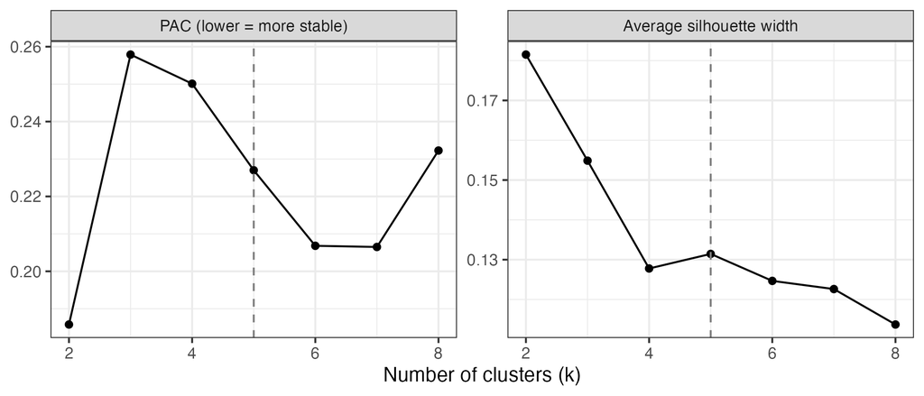

**Figure S6.** Choosing k. Left: PAC (proportion of ambiguous clustering; share of tumor pairs with consensus between 0.1 and 0.9 over 200 resamples of 80% of tumors and genes; lower = more stable). Right: average silhouette width of PAM on all tumors. Dashed line: chosen k = 5.

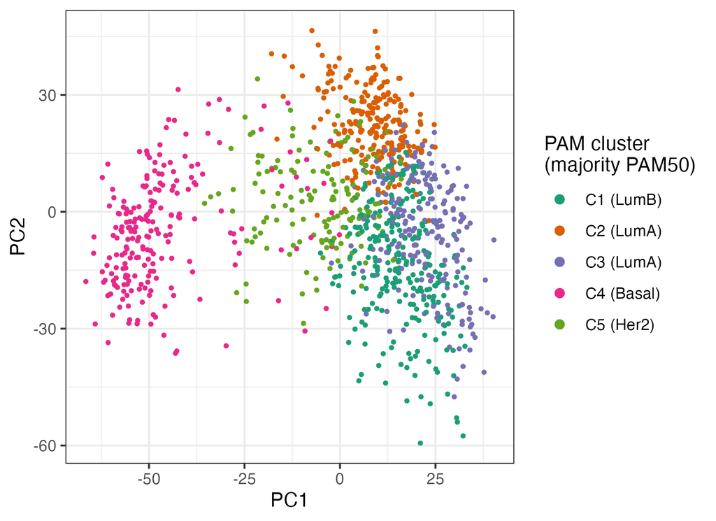

**Figure S7.** Primary tumors on PC1 and PC2 (from Section 1.2), colored by PAM cluster. Labels give each cluster’s most common PAM50 subtype.

**Table S16.** Cluster robustness. Adjusted Rand index vs. the main clusters (same k only). Cluster columns: % of each main cluster’s tumors that fall in their best-matching cluster in the alternative version. Several main clusters can map to the same alternative cluster, so recovery is generous, most at k = 6–7.

| Version | Adjusted Rand index | C1 (LumB) | C2 (LumA) | C3 (LumA) | C4 (Basal) | C5 (Her2) |
| --- | --- | --- | --- | --- | --- | --- |
| Top 1000 genes | 0.85 | 93 | 92 | 96 | 97 | 91 |
| Top 5000 genes | 0.44 | 75 | 71 | 41 | 90 | 68 |
| Consensus (top 2000) | 0.89 | 97 | 95 | 98 | 96 | 87 |
| k = 6 | – | 88 | 77 | 91 | 94 | 79 |
| k = 7 | – | 83 | 55 | 78 | 92 | 72 |

**Table S17.** PAM cluster vs. PAM50 subtype (genefu, robust centroids): number of tumors.

| Cluster | LumA | LumB | Her2 | Basal | Normal |
| --- | --- | --- | --- | --- | --- |
| C1 (LumB) | 52 | 195 | 11 | 0 | 0 |
| C2 (LumA) | 195 | 26 | 0 | 2 | 14 |
| C3 (LumA) | 127 | 96 | 0 | 0 | 0 |
| C4 (Basal) | 3 | 9 | 8 | 193 | 6 |
| C5 (Her2) | 18 | 46 | 89 | 1 | 2 |

## S10. Clusters, clinical features and batch

Each feature was tested against cluster **(Table S18)**:

- **Categorical features:** chi-square test (simulated p, 10,000 draws) with bias-corrected Cramér’s V. Among these, ER, PR and PAM50 are most strongly associated.
- **Continuous features:** Kruskal–Wallis test with ε². Among these, purity and ERBB2 mRNA are most strongly associated.

**Batch** **(Table S19)**. Era vs. cluster was tested within histology (generalized Cochran–Mantel–Haenszel, ductal and lobular strata), then within histology × ER status, then within ductal tumors by ER.

- **Within histology:** cluster is associated with era (p <0.001). Much of this is case mix: later-era ductal tumors are more often ER− by IHC (38% vs. 25%), a measurement independent of RNA. After also stratifying by ER, the association weakens but remains (p <0.001).
- **ER− ductal tumors:** no era effect (p = 0.564).
- **ER+ ductal tumors:** an era effect remains (p = 0.001). Later-era ER+ ductal tumors are in C4 (Basal) 16% of the time vs. 5% earlier, and in C5 21% vs. 14%. The C4 excess may be technical, or ER-low tumors (1–10% staining) recorded as ER+.
- **Plate vs. cluster in ductal tumors:** weak (bias-corrected Cramér’s V 0.11, p = 0.011). It may partly reflect which sites contributed to each plate.

These are reported as caveats. Clusters were not corrected for era (Section 1.3).

**Table S18.** PAM cluster vs. clinical and molecular features. Cramér’s V is bias-corrected. HER2 status: HER2+ vs. HER2− (Table 1). HER2 category: HER2-0, HER2-low 1+, HER2-low 2+ and HER2+ (tumors without a numeric score excluded). Histology: ductal, lobular, other. Simulated p values have a floor of 1/10,001. p values BH-adjusted.

| Variable | Tumors | Test | Effect | p (BH) |
| --- | --- | --- | --- | --- |
| PAM50 | 1093 | Chi-square (simulated p) | Cramer’s V = 0.62 | <0.001 |
| HER2 status | 929 | Chi-square (simulated p) | Cramer’s V = 0.44 | <0.001 |
| HER2 category | 625 | Chi-square (simulated p) | Cramer’s V = 0.28 | <0.001 |
| ERBB2 GISTIC | 960 | Chi-square (simulated p) | Cramer’s V = 0.31 | <0.001 |
| ER | 1043 | Chi-square (simulated p) | Cramer’s V = 0.74 | <0.001 |
| PR | 1040 | Chi-square (simulated p) | Cramer’s V = 0.65 | <0.001 |
| Histology | 1093 | Chi-square (simulated p) | Cramer’s V = 0.31 | <0.001 |
| Era | 1093 | Chi-square (simulated p) | Cramer’s V = 0.10 | 0.004 |
| ERBB2 mRNA | 1093 | Kruskal-Wallis | epsilon^2 = 0.22 | <0.001 |
| ESTIMATE score | 1093 | Kruskal-Wallis | epsilon^2 = 0.23 | <0.001 |
| Age | 1092 | Kruskal-Wallis | epsilon^2 = 0.03 | <0.001 |

**Table S19.** PAM cluster vs. processing era and plate. CMH: generalized Cochran–Mantel–Haenszel test stratified by histology (ductal, lobular), or by histology × ER status. Cramér’s V is bias-corrected.

| Test | p | Cramér’s V |
| --- | --- | --- |
| Era vs cluster \| histology (CMH) | <0.001 | – |
| Era vs cluster \| histology x ER (CMH) | <0.001 | – |
| Era vs cluster, ductal only (chi-square, simulated p) | <0.001 | 0.18 |
| Era vs cluster, ER+ ductal (chi-square, simulated p) | 0.001 | 0.16 |
| Era vs cluster, ER- ductal (chi-square, simulated p) | 0.564 | 0.00 |
| Plate vs cluster, ductal only (chi-square, simulated p) | 0.011 | 0.11 |

## S11. The two ERBB2 groups in C5

**Split.** C5 was split at the minimum of the ERBB2 mRNA kernel density between 13 and 16 VST (default bandwidth; 14.92). The split is robust:

- **Bandwidth:** with the bandwidth scaled from 0.5 to 1.5 times the default, the minimum stays between 14.77 and 14.95.
- **Gaussian mixture:** a two-component Gaussian mixture is strongly preferred over one (BIC -643 vs. -714; higher is better). It places 84 tumors in the lower component, vs. 83 by the density split.

**Purity** **(Table S20)**. Purity was summarized by the ESTIMATE score and by stromal and immune marker scores (mean z-score of COL1A1, FAP, COL3A1, and of PTPRC, CD8A, CD3E).

**Table S20.** Purity and infiltration of the two C5 groups. ESTIMATE: higher = lower purity. Stroma and immune markers: median of each tumor’s mean z-score (across all tumors) of COL1A1, FAP, COL3A1 and of PTPRC, CD8A, CD3E.

| Group | Tumors | Median ESTIMATE | Stroma markers | Immune markers |
| --- | --- | --- | --- | --- |
| C5 ERBB2-high | 73 | 9 | 0.52 | 0.03 |
| C5 ERBB2-low | 83 | 675 | 0.73 | 0.42 |

**Fit to C5.** The ERBB2-low group fits C5 less well than the ERBB2-high group:

- **Silhouette:** median 0.05 vs. 0.09, and negative in 24% vs. 11%.
- **Consensus clustering:** keeps 80% vs. 95% in C5.
- **Nearest other cluster:** spread across C4, C1 and C2 **(Table S21)**.

Reported-only labels, which are noisy at some sites (Section 2.2), are more common in the ERBB2-low group.

**The 13 HER2+ tumors in the ERBB2-low group** **(Table S22)**:

- **IHC 2+/FISH+:** 5 tumors (3 from site A8; 2 amplified). These may be borderline ISH results (Section 2.1).
- **Site A8, IHC 3+/FISH+:** 1 tumor with a low-level gain (Section 2.3).
- **Reported status only:** 4 tumors from sites BH and E9 (Section 2.2).
- **IHC 3+ with negative FISH:** 2 tumors, including TCGA-A2-A0EQ-01 **(Supplement S8)**.
- **IHC 3+ without FISH or amplification:** 1 tumor.

**Table S21.** C5 tumors in the ERBB2-high and ERBB2-low groups: number of tumors per category, then cluster-fit measures and purity. Nearest other cluster: the cluster each tumor would join next (PAM silhouette neighbor). ESTIMATE: higher = lower purity.

| Feature | Value | ERBB2-high | ERBB2-low |
| --- | --- | --- | --- |
| ERBB2 GISTIC | 1 | 2 | 16 |
| ERBB2 GISTIC | 2 | 64 | 5 |
| ERBB2 GISTIC | NA | 7 | 13 |
| ERBB2 GISTIC | -1 | 0 | 34 |
| ERBB2 GISTIC | -2 | 0 | 1 |
| ERBB2 GISTIC | 0 | 0 | 14 |
| HER2 status | Missing | 6 | 5 |
| HER2 status | Positive | 67 | 13 |
| HER2 status | Conflict | 0 | 2 |
| HER2 status | Negative | 0 | 59 |
| HER2 status | Unresolved | 0 | 4 |
| HER2 category | Positive | 67 | 13 |
| HER2 category | NA | 6 | 11 |
| HER2 category | HER2-0 | 0 | 3 |
| HER2 category | HER2-low 1+ | 0 | 22 |
| HER2 category | HER2-low 2+ | 0 | 9 |
| HER2 category | Negative, no score | 0 | 25 |
| PAM50 | Her2 | 62 | 27 |
| PAM50 | LumA | 1 | 17 |
| PAM50 | LumB | 10 | 36 |
| PAM50 | Basal | 0 | 1 |
| PAM50 | Normal | 0 | 2 |
| ER | Negative | 34 | 18 |
| ER | Positive | 38 | 62 |
| ER | NA | 1 | 3 |
| Era | Plate A213 and after | 12 | 24 |
| Era | Plates before A213 | 61 | 59 |
| Label source | FISH only | 2 | 4 |
| Label source | None | 6 | 5 |
| Label source | Numeric IHC score | 56 | 48 |
| Label source | Reported IHC status only | 9 | 26 |
| Median silhouette |  | 0.09 | 0.05 |
| Negative silhouette (%) |  | 11 | 24 |
| Kept in C5 by consensus (%) |  | 95 | 80 |
| Nearest other cluster |  | C4: 41, C3: 18, C1: 13, C2: 1 | C4: 31, C1: 23, C2: 20, C3: 9 |
| Median ESTIMATE |  | 9 | 675 |

**Table S22.** Clinically HER2+ tumors in the ERBB2-low group of C5. Rule: how HER2 status was set (Table S5).

| Sample | Site | ERBB2 mRNA | GISTIC | IHC score | FISH | Rule | PAM50 |
| --- | --- | --- | --- | --- | --- | --- | --- |
| TCGA-A2-A0EQ-01 | A2 | 12.6 | 0 | 3+ | Negative | IHC score 3+, FISH Negative | Her2 |
| TCGA-A8-A06R-01 | A8 | 11.3 | -1 | 2+ | Positive | IHC score 2+, FISH Positive | LumB |
| TCGA-A8-A075-01 | A8 | 12.2 | -1 | 2+ | Positive | IHC score 2+, FISH Positive | LumB |
| TCGA-A8-A08P-01 | A8 | 13.5 | 1 | 3+ | Positive | IHC score 3+, FISH Positive | LumB |
| TCGA-A8-A097-01 | A8 | 14.9 | 2 | 2+ | Positive | IHC score 2+, FISH Positive | LumB |
| TCGA-AQ-A04L-01 | AQ | 13.0 | -1 | 3+ | – | IHC score 3+ | Her2 |
| TCGA-BH-A0B6-01 | BH | 11.9 | -2 | – | – | Reported IHC Positive | LumA |
| TCGA-BH-A18P-01 | BH | 13.6 | 1 | 2+ | Positive | IHC score 2+, FISH Positive | Her2 |
| TCGA-E9-A1N6-01 | E9 | 13.8 | – | – | – | Reported IHC Positive | LumB |
| TCGA-E9-A22E-01 | E9 | 11.0 | -1 | – | – | Reported IHC Positive | LumB |
| TCGA-E9-A3X8-01 | E9 | 12.6 | -1 | – | – | Reported IHC Positive | LumA |
| TCGA-LL-A5YL-01 | LL | 13.6 | 0 | 3+ | Negative | IHC score 3+, FISH Negative | Her2 |
| TCGA-LL-A5YN-01 | LL | 13.8 | 2 | 2+ | Positive | IHC score 2+, FISH Positive | LumA |

## S12. Elastic net and compact models: details

**C5 ERBB2-low vs. the luminal clusters.** 43 genes are stable: 26 lower and 17 higher in the ERBB2-low group **(Figure 8, Figure S8)**.

- **Lower:** two kinds of genes.
  - **Luminal, ER-associated genes:** including the PAM50 genes PGR, BCL2 and MAPT [14], and ELOVL2, GFRA1, SERPINA3 and IGF1R. They are lower than in every luminal cluster, although 78% of the group is ER+ by IHC.
  - **Adipose and endothelial genes:** CAVIN2, MMRN1, TMEM132C, PCK1, EDNRB, TIMP4 and SEMA3G. These are high mainly in C2, the cluster with the most normal-breast and stromal content, so they reflect the comparator’s tissue mix rather than tumor-cell biology.
- **Higher:** VSTM2L, KRT86, MMP1, TMEM45A, S100A9, SOX11 and MFSD2A.
- **Between luminal and non-luminal tumors:** on these genes the ERBB2-low group sits between the luminal clusters and both C5 ERBB2-high and C4 (Basal) (median z of the lower genes -0.51, vs. -0.70 and -0.82). Its profile matches C5 ERBB2-high slightly better than C4 (Pearson r 0.91 vs. 0.77); both correlations are high by construction and their difference was not tested.
- **Mostly not tracking infiltration:** every model includes purity, and two direct checks agree **(Table S25)**.
  - **Purity-matched comparison:** each tumor was matched to 3 luminal tumors of similar purity by ESTIMATE (median 669 vs. 675). All 43 genes keep their direction, and the differences are a median 96% of the unmatched ones. The ER-associated genes PGR, GFRA1, SERPINA3 and ELOVL2 are lower by about 2 VST units either way. The adipose and endothelial genes differ more after matching (e.g. CAVIN2 −0.70 to −1.32), as expected if they come from the comparator’s tissue mix.
  - **Correlation within luminal tumors** (so that group membership cannot drive it): most genes correlate weakly with stromal and immune marker scores (median |Spearman ρ| 0.12 and 0.14). Seven reach |ρ| ≥ 0.4 with ESTIMATE, stroma or immune: TMEM45A and SOX11 (stroma), S100A9, CAVIN2, MMRN1 and TMEM132C (ESTIMATE or immune), and RERG.
  - **Reading these:** only the three higher in C5 ERBB2-low (TMEM45A, SOX11, S100A9) could be inflated by infiltration, and their purity-matched differences stay large (1.1–2.4 VST units). CAVIN2, MMRN1 and TMEM132C rise with infiltration yet are lower in this least-pure group, so infiltration masks rather than causes their difference.

**C5 ERBB2-low vs. C5 ERBB2-high.** Besides the amplicon, 8 stable genes are higher (including RIPPLY3, ALOX15, MSI1 and RERG) and 4 lower (TOB1, USP18, ITGB6, GALNT7) in the ERBB2-low group, with smaller differences (0.3–1.7 VST units). STARD3 was the top gene in 94% of training sets (GRB7 or PGAP3 otherwise); the full elastic net reaches CV AUC 0.999.

**Elastic net.** Genes were standardized internally before penalization; coefficients in **(Table S23)** are on the standardized scale (β × SD of the gene within the contrast). The 5,000 genes are a superset of the 2,000 used for clustering. The 1-SE choice of λ gives sparser, more reproducible gene sets than the λ with the lowest CV deviance. Selection frequency counts how often a gene has a non-zero coefficient across the 100 training sets. It is more reliable than a single fit, because the lasso part of the penalty picks one of a group of correlated genes somewhat arbitrarily. The training sets overlap heavily, so the frequencies are descriptive and the 70% cut-off has no error-rate guarantee. All random folds (outer and inner) were drawn before fitting, so results do not depend on the computer.

**Compact models.** In each training set, the genes were the $m$ largest standardized coefficients of that set’s elastic net ($m$ = 1–20), fitted by ordinary (maximum-likelihood) logistic regression, so the test fold never informs gene choice. $m$ is the smallest within 0.01 AUC of the best compact model. The final genes are those most often in the in-fold top $m$ (column “In top m (%)” of Table S23, m = 7), fitted on all tumors by Firth’s penalized logistic regression, which keeps coefficients finite when the groups are almost perfectly separated; CIs are profile-likelihood **(Table S24)**. Choosing instead by full-data coefficient would swap BCL2 and TMEM45A for NKAIN1 and ENTREP1, which were in the in-fold top 7 in under a quarter of training sets. TMEM45A partly tracks stroma **(Table S25)**. The number of genes was chosen on the same CV results, so the compact AUCs are slightly optimistic **(Figure S9)**:

- **C1–C3:** AUC rises steeply to about 6 genes and changes little after 7 (0.964 at 7, best 0.973 at 15 genes).
- **C5 ERBB2-high:** one gene is enough.

Paired comparisons used the corrected repeated k-fold t-test (as in Supplement S7), BH-adjusted across the five comparisons **(Table S26)**.

**Sensitivity** **(Table S27)**. The full-data elastic net was refitted, with the same inner folds, (a) without the purity term, and (b) with processing era and lobular histology added as unpenalized covariates. Overlap with the main gene set was measured by the Jaccard index (shared / union).

- **vs. C5 ERBB2-high:** dropping purity changes little (Jaccard 0.85); adding era and histology changes more (0.56).
- **vs. C1–C3:** Jaccard 0.55 without purity (108 genes selected vs. 98) and 0.71 with era and histology; 73–80 of the 98 main genes stay selected.

Moderate overlap is expected for single elastic net fits on correlated genes, which is why selection frequency across training sets is the main criterion.

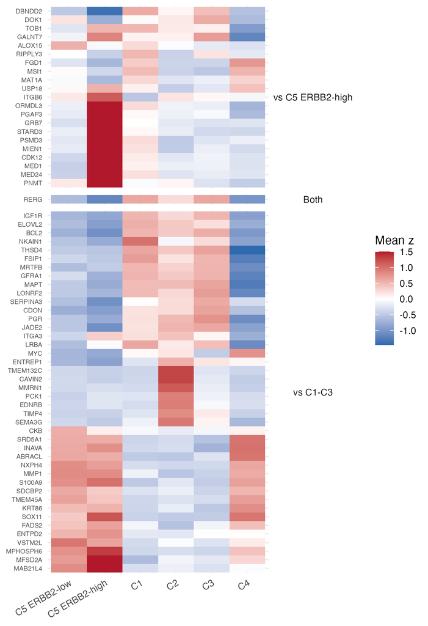

**Figure S8.** Stable genes (selected in ≥70% of training sets) by group: mean z-score across all primary tumors, capped at ±1.5. Rows are grouped by the contrast in which each gene is stable: vs. C5 ERBB2-high (top), both contrasts (RERG: higher than in C5 ERBB2-high but lower than in C1–C3), and vs. C1–C3 (bottom); within blocks, ordered by hierarchical clustering. C4 is shown for reference. Current gene symbols.

**Table S23.** Stable genes (selected in ≥70% of 100 CV training sets) per contrast; current symbol, with the TCGA symbol in brackets where it has changed. Coefficient: full-data elastic net, β × SD of the gene (0 = not selected in the full-data fit). Difference: mean VST in C5 ERBB2-low minus the comparator (positive = higher in C5 ERBB2-low). In top m: % of training sets in which the gene was among the compact model’s top m genes (m = 1 vs. C5 ERBB2-high, 7 vs. C1–C3).

| C5 ERBB2-low vs. | Gene | Selected (%) | Coefficient (standardized) | Mean VST, C5-low | Mean VST, comparator | Difference | In top m (%) |
| --- | --- | --- | --- | --- | --- | --- | --- |
| C5 ERBB2-high | STARD3 | 100 | -0.91 | 9.9 | 13.0 | -3.08 | 94 |
| C5 ERBB2-high | GRB7 | 100 | -0.84 | 9.0 | 12.8 | -3.78 | 4 |
| C5 ERBB2-high | PGAP3 | 100 | -0.83 | 9.9 | 13.2 | -3.30 | 2 |
| C5 ERBB2-high | MIEN1 (C17orf37) | 100 | -0.73 | 9.9 | 13.1 | -3.25 | 0 |
| C5 ERBB2-high | MED1 | 100 | -0.29 | 10.4 | 12.6 | -2.22 | 0 |
| C5 ERBB2-high | CDK12 | 100 | -0.19 | 10.3 | 12.2 | -1.86 | 0 |
| C5 ERBB2-high | PSMD3 | 100 | -0.12 | 11.5 | 13.9 | -2.36 | 0 |
| C5 ERBB2-high | ORMDL3 | 99 | -0.15 | 11.1 | 13.7 | -2.60 | 0 |
| C5 ERBB2-high | RIPPLY3 (DSCR6) | 98 | 0.21 | 6.4 | 6.0 | 0.39 | 0 |
| C5 ERBB2-high | ALOX15 | 97 | 0.17 | 6.5 | 5.9 | 0.67 | 0 |
| C5 ERBB2-high | MSI1 | 96 | 0.17 | 6.7 | 6.2 | 0.49 | 0 |
| C5 ERBB2-high | TOB1 | 93 | -0.14 | 11.1 | 11.9 | -0.79 | 0 |
| C5 ERBB2-high | MED24 | 87 | -0.15 | 10.5 | 12.3 | -1.86 | 0 |
| C5 ERBB2-high | RERG | 85 | 0.14 | 9.0 | 8.2 | 0.81 | 0 |
| C5 ERBB2-high | MAT1A | 84 | 0.12 | 5.9 | 5.3 | 0.67 | 0 |
| C5 ERBB2-high | GALNT7 | 81 | -0.07 | 10.8 | 12.0 | -1.15 | 0 |
| C5 ERBB2-high | DOK1 | 79 | 0.09 | 8.7 | 7.9 | 0.82 | 0 |
| C5 ERBB2-high | DBNDD2 | 77 | 0.10 | 9.6 | 8.7 | 0.91 | 0 |
| C5 ERBB2-high | PNMT | 73 | -0.09 | 6.3 | 8.9 | -2.61 | 0 |
| C5 ERBB2-high | ITGB6 | 71 | -0.09 | 10.1 | 11.8 | -1.73 | 0 |
| C5 ERBB2-high | FGD1 | 70 | 0.12 | 8.7 | 8.3 | 0.34 | 0 |
| C5 ERBB2-high | USP18 | 70 | -0.12 | 9.0 | 9.5 | -0.46 | 0 |
| C1-C3 | MAPT | 100 | -0.31 | 9.2 | 11.4 | -2.18 | 96 |
| C1-C3 | VSTM2L | 100 | 0.31 | 7.8 | 6.3 | 1.54 | 98 |
| C1-C3 | KRT86 | 100 | 0.22 | 6.9 | 5.9 | 1.06 | 76 |
| C1-C3 | JADE2 (PHF15) | 100 | -0.21 | 9.6 | 10.4 | -0.82 | 77 |
| C1-C3 | MMP1 | 100 | 0.19 | 9.4 | 7.0 | 2.44 | 63 |
| C1-C3 | ENTREP1 (FAM189A2) | 99 | -0.17 | 6.6 | 7.7 | -1.04 | 17 |
| C1-C3 | EDNRB | 99 | -0.14 | 7.4 | 7.9 | -0.51 | 8 |
| C1-C3 | NKAIN1 | 98 | -0.18 | 7.5 | 9.5 | -2.05 | 22 |
| C1-C3 | BCL2 | 98 | -0.12 | 9.3 | 11.0 | -1.74 | 50 |
| C1-C3 | TMEM45A | 97 | 0.16 | 9.8 | 8.5 | 1.22 | 31 |
| C1-C3 | MAB21L4 (C2orf54) | 97 | 0.16 | 8.5 | 6.7 | 1.89 | 21 |
| C1-C3 | ENTPD2 | 97 | 0.12 | 8.6 | 7.9 | 0.71 | 6 |
| C1-C3 | S100A9 | 96 | 0.13 | 10.6 | 7.6 | 3.02 | 10 |
| C1-C3 | CKB | 95 | 0.13 | 9.9 | 8.8 | 1.04 | 10 |
| C1-C3 | NXPH4 | 95 | 0.07 | 7.8 | 6.3 | 1.47 | 4 |
| C1-C3 | ITGA3 | 93 | -0.13 | 10.3 | 10.9 | -0.63 | 10 |
| C1-C3 | CDON | 93 | -0.12 | 8.2 | 9.4 | -1.20 | 11 |
| C1-C3 | LONRF2 | 92 | -0.15 | 8.0 | 9.7 | -1.64 | 9 |
| C1-C3 | ELOVL2 | 92 | -0.11 | 7.0 | 9.2 | -2.18 | 7 |
| C1-C3 | CAVIN2 (SDPR) | 92 | -0.10 | 7.0 | 7.7 | -0.70 | 1 |
| C1-C3 | INAVA (C1orf106) | 92 | 0.10 | 9.0 | 7.2 | 1.88 | 9 |
| C1-C3 | FSIP1 | 90 | -0.10 | 7.0 | 8.5 | -1.49 | 9 |
| C1-C3 | RERG | 90 | -0.06 | 9.0 | 10.7 | -1.72 | 4 |
| C1-C3 | MFSD2A | 89 | 0.10 | 8.1 | 6.9 | 1.16 | 13 |
| C1-C3 | MYC | 88 | -0.10 | 9.9 | 10.6 | -0.71 | 2 |
| C1-C3 | SOX11 | 88 | 0.05 | 7.8 | 6.4 | 1.40 | 1 |
| C1-C3 | SERPINA3 | 87 | -0.11 | 12.0 | 13.8 | -1.81 | 7 |
| C1-C3 | SEMA3G | 87 | -0.06 | 8.2 | 9.0 | -0.74 | 0 |
| C1-C3 | THSD4 | 87 | 0.00 | 9.8 | 11.7 | -1.89 | 0 |
| C1-C3 | MRTFB (MKL2) | 86 | -0.09 | 10.5 | 11.4 | -0.92 | 0 |
| C1-C3 | PGR | 86 | -0.07 | 8.0 | 10.8 | -2.77 | 6 |
| C1-C3 | SRD5A1 | 83 | 0.07 | 9.0 | 8.0 | 1.01 | 1 |
| C1-C3 | MMRN1 | 83 | -0.07 | 6.4 | 7.1 | -0.68 | 1 |
| C1-C3 | TMEM132C | 82 | -0.05 | 5.5 | 6.1 | -0.59 | 0 |
| C1-C3 | LRBA | 78 | -0.10 | 10.9 | 11.9 | -0.94 | 1 |
| C1-C3 | FADS2 | 76 | 0.12 | 11.6 | 10.3 | 1.27 | 5 |
| C1-C3 | PCK1 | 76 | -0.05 | 5.3 | 6.0 | -0.65 | 0 |
| C1-C3 | MPHOSPH6 | 75 | 0.03 | 9.3 | 8.4 | 0.95 | 1 |
| C1-C3 | TIMP4 | 74 | -0.08 | 5.9 | 6.6 | -0.74 | 0 |
| C1-C3 | IGF1R | 73 | -0.04 | 10.6 | 12.3 | -1.71 | 1 |
| C1-C3 | SDCBP2 | 72 | 0.06 | 7.4 | 6.6 | 0.78 | 1 |
| C1-C3 | ABRACL (C6orf115) | 71 | 0.01 | 10.1 | 9.2 | 0.90 | 1 |
| C1-C3 | GFRA1 | 70 | -0.07 | 10.2 | 12.5 | -2.33 | 0 |

**Table S24.** Final compact logistic models, fitted on all tumors of each contrast by Firth’s penalized logistic regression (equation in Section 4.1), with profile-likelihood 95% CI and p. Genes are z-scored within the contrast (TCGA symbol in brackets where it has changed); purity is ESTIMATE / 1,000. The STARD3 model almost separates the two C5 groups, so its coefficient is large and imprecise.

| C5 ERBB2-low vs. | Term | β (95% CI) | OR per SD | p |
| --- | --- | --- | --- | --- |
| C5 ERBB2-high | Intercept | -0.54 (-1.85 to 0.58) | – | 0.351 |
| C5 ERBB2-high | Purity | 0.37 (-0.58 to 1.40) | – | 0.442 |
| C5 ERBB2-high | STARD3 | -6.44 (-10.47 to -4.19) | 1.6 × 10⁻³ | <0.001 |
| C1-C3 | Intercept | -6.02 (-7.51 to -4.86) | – | <0.001 |
| C1-C3 | Purity | 1.17 (0.76 to 1.65) | – | <0.001 |
| C1-C3 | VSTM2L | 1.19 (0.77 to 1.67) | 3.29 | <0.001 |
| C1-C3 | MAPT | -1.29 (-1.83 to -0.82) | 0.27 | <0.001 |
| C1-C3 | JADE2 (PHF15) | -0.88 (-1.43 to -0.38) | 0.42 | <0.001 |
| C1-C3 | KRT86 | 1.10 (0.58 to 1.66) | 2.99 | <0.001 |
| C1-C3 | MMP1 | 0.61 (0.19 to 1.06) | 1.84 | 0.004 |
| C1-C3 | BCL2 | -0.99 (-1.57 to -0.48) | 0.37 | <0.001 |
| C1-C3 | TMEM45A | 0.94 (0.41 to 1.53) | 2.55 | <0.001 |

**Table S25.** Purity checks for the stable genes from the C5 ERBB2-low vs. C1–C3 contrast. Difference: mean VST in C5 ERBB2-low minus all C1–C3 tumors. Purity-matched: minus the 3 C1–C3 tumors nearest in ESTIMATE to each C5 ERBB2-low tumor (with replacement). ρ: Spearman correlation within C1–C3 tumors with ESTIMATE (higher = lower purity) and with stromal and immune marker scores (mean z of COL1A1, FAP, COL3A1 and of PTPRC, CD8A, CD3E; as in Table S20). Sorted by the largest |ρ|.

| Gene | Difference | Difference, purity-matched | ρ ESTIMATE | ρ stroma | ρ immune |
| --- | --- | --- | --- | --- | --- |
| TMEM45A | 1.22 | 1.10 | 0.26 | 0.49 | -0.03 |
| MMRN1 | -0.68 | -1.18 | 0.48 | 0.24 | 0.48 |
| TMEM132C | -0.59 | -1.10 | 0.48 | 0.32 | 0.44 |
| CAVIN2 (SDPR) | -0.70 | -1.32 | 0.48 | 0.24 | 0.46 |
| RERG | -1.72 | -1.41 | -0.44 | -0.39 | -0.29 |
| SOX11 | 1.40 | 1.37 | 0.11 | 0.43 | -0.14 |
| S100A9 | 3.02 | 2.42 | 0.41 | 0.26 | 0.31 |
| MMP1 | 2.44 | 2.37 | 0.15 | 0.38 | 0.01 |
| SEMA3G | -0.74 | -1.14 | 0.37 | 0.14 | 0.29 |
| THSD4 | -1.89 | -1.46 | -0.36 | -0.25 | -0.29 |
| EDNRB | -0.51 | -0.84 | 0.35 | 0.09 | 0.34 |
| PCK1 | -0.65 | -1.14 | 0.32 | 0.12 | 0.32 |
| TIMP4 | -0.74 | -1.09 | 0.30 | 0.12 | 0.22 |
| IGF1R | -1.71 | -1.36 | -0.30 | -0.19 | -0.21 |
| LRBA | -0.94 | -0.70 | -0.27 | -0.12 | -0.19 |
| KRT86 | 1.06 | 0.90 | 0.26 | 0.16 | 0.25 |
| VSTM2L | 1.54 | 1.45 | 0.25 | 0.24 | 0.20 |
| MAB21L4 (C2orf54) | 1.89 | 1.64 | 0.16 | 0.24 | 0.11 |
| BCL2 | -1.74 | -1.52 | -0.20 | -0.23 | -0.12 |
| LONRF2 | -1.64 | -1.39 | -0.22 | -0.15 | -0.18 |
| MFSD2A | 1.16 | 1.10 | 0.22 | 0.16 | 0.18 |
| NXPH4 | 1.47 | 1.50 | 0.15 | 0.22 | 0.02 |
| MAPT | -2.18 | -1.93 | -0.20 | 0.01 | -0.21 |
| NKAIN1 | -2.05 | -1.60 | -0.21 | -0.07 | -0.15 |
| MRTFB (MKL2) | -0.92 | -0.73 | -0.20 | -0.02 | -0.15 |
| INAVA (C1orf106) | 1.88 | 1.70 | 0.11 | 0.11 | 0.18 |
| ENTPD2 | 0.71 | 0.87 | -0.17 | -0.10 | -0.14 |
| FSIP1 | -1.49 | -1.21 | -0.15 | -0.07 | -0.12 |
| MYC | -0.71 | -0.84 | 0.03 | -0.07 | 0.14 |
| CDON | -1.20 | -0.92 | -0.12 | -0.05 | -0.14 |
| JADE2 (PHF15) | -0.82 | -0.79 | -0.00 | -0.14 | 0.01 |
| GFRA1 | -2.33 | -2.23 | -0.13 | -0.07 | -0.07 |
| ENTREP1 (FAM189A2) | -1.04 | -1.16 | 0.12 | 0.13 | 0.04 |
| SRD5A1 | 1.01 | 0.95 | 0.09 | 0.11 | 0.13 |
| SDCBP2 | 0.78 | 0.77 | 0.11 | 0.09 | 0.02 |
| MPHOSPH6 | 0.95 | 0.96 | -0.04 | -0.11 | 0.06 |
| SERPINA3 | -1.81 | -1.87 | -0.02 | -0.01 | -0.10 |
| CKB | 1.04 | 1.08 | -0.06 | -0.07 | -0.04 |
| ELOVL2 | -2.18 | -2.11 | -0.07 | 0.00 | -0.04 |
| PGR | -2.77 | -2.73 | -0.01 | 0.06 | -0.06 |
| FADS2 | 1.27 | 1.29 | -0.04 | -0.00 | -0.04 |
| ITGA3 | -0.63 | -0.59 | 0.03 | 0.04 | -0.04 |
| ABRACL (C6orf115) | 0.90 | 0.86 | 0.02 | -0.02 | 0.00 |

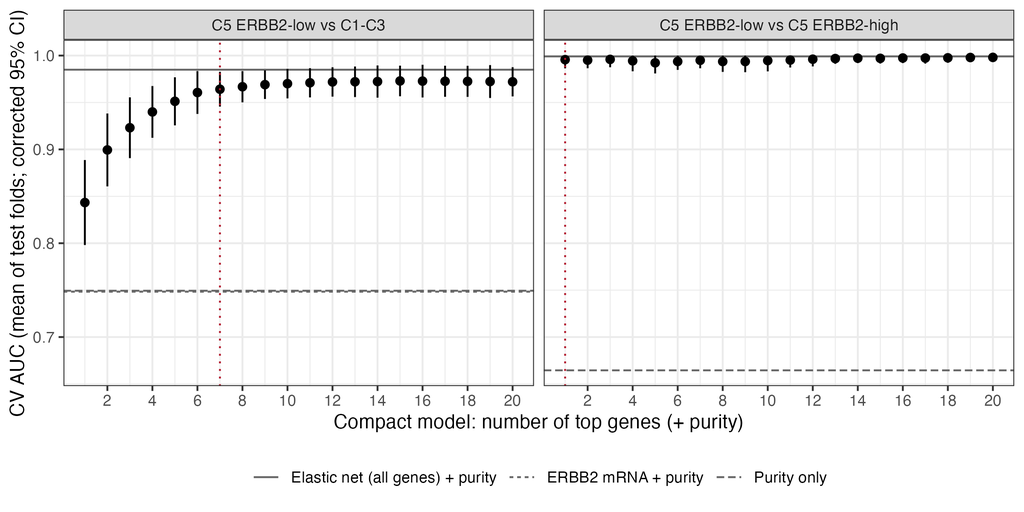

**Figure S9.** CV AUC of the compact logistic model by number of top genes (mean over test folds, corrected 95% CI capped at 1), with reference lines for the full elastic net, ERBB2 mRNA + purity and purity alone. All models include purity. Dotted red line: chosen number of genes.

**Table S26.** Paired comparisons of the compact model with the other models (compact minus other): mean AUC difference over test folds, with corrected repeated k-fold t-test CI and p, BH-adjusted across the five comparisons.

| C5 ERBB2-low vs. | Comparison | AUC difference (95% CI) | p | p (BH) |
| --- | --- | --- | --- | --- |
| C5 ERBB2-high | Compact (top 1 genes) + purity vs. Purity only | 0.331 (0.252 to 0.410) | <0.001 | <0.001 |
| C5 ERBB2-high | Compact (top 1 genes) + purity vs. Elastic net (all genes) + purity | -0.003 (-0.012 to 0.005) | 0.433 | 0.433 |
| C1-C3 | Compact (top 7 genes) + purity vs. Purity only | 0.215 (0.165 to 0.265) | <0.001 | <0.001 |
| C1-C3 | Compact (top 7 genes) + purity vs. ERBB2 mRNA + purity | 0.216 (0.166 to 0.266) | <0.001 | <0.001 |
| C1-C3 | Compact (top 7 genes) + purity vs. Elastic net (all genes) + purity | -0.021 (-0.036 to -0.006) | 0.008 | 0.010 |

**Table S27.** Sensitivity of elastic net gene selection (full-data fits, same inner folds) to the covariates. Main model: purity unpenalized. Jaccard: shared genes / all genes selected by either model.

| C5 ERBB2-low vs. | Model | Genes (main) | Genes (sensitivity) | Shared | Jaccard |
| --- | --- | --- | --- | --- | --- |
| C5 ERBB2-high | No purity covariate | 72 | 67 | 64 | 0.85 |
| C5 ERBB2-high | Purity + era + lobular | 72 | 62 | 48 | 0.56 |
| C1-C3 | No purity covariate | 98 | 108 | 73 | 0.55 |
| C1-C3 | Purity + era + lobular | 98 | 94 | 80 | 0.71 |

## S13. Differential expression, pathways and immune cells: details

**Differential expression.** VST shrinks fold changes of low-expressed genes, so the TREAT threshold is conservative for them. The C1–C3 pooled mean uses all 718 luminal tumors (Step 4 used 717, dropping one tumor without histology).

**camera check of the Hallmark results** **(Table S28)**. fgsea permutes genes, not tumors, so it ignores correlation between genes. camera tests the same design and contrasts while allowing for inter-gene correlation, in two settings: limma’s small preset correlation (0.01, default) and each set’s own correlation estimated from the data (strict), under which strongly co-expressed programs such as proliferation count as only a few independent genes.

Of the 50 Hallmark sets, fgsea calls 31 (unadjusted) and 21 (purity-adjusted) significant vs. C1–C3, and 25 and 9 vs. C5 ERBB2-high. camera with the default correlation keeps 27, 18, 15 and 6; with the estimated correlation, 1, 3, 0 and 0. Estimated correlations are high for strongly co-expressed programs (vs. C1–C3, unadjusted: E2F targets 0.22, allograft rejection 0.22, vs. 0.04 for early estrogen response), which shrinks their effective number of genes. With the strict setting, only early estrogen response (both models), glycolysis and mTORC1 signalling (purity-adjusted) remain significant vs. C1–C3, and nothing vs. C5 ERBB2-high.

The stable Step 4 genes fall in the leading edges of 8 significant Hallmark sets vs. C1–C3 (e.g. BCL2, MAPT and PGR in estrogen response, TMEM45A in hypoxia, MMP1 in EMT). Strongly differential genes almost always sit in leading edges, so this annotates the genes rather than adding evidence. Reactome pathways (fgsea only) give the finer form of the same picture: immune pathways lead without adjustment, translation, respiratory electron transport and DNA replication after adjustment, and estrogen-dependent gene expression is lower in both models.

**Table S28.** Hallmark sets discussed in Section 5.3: fgsea NES (positive = higher in C5 ERBB2-low) with BH-adjusted p, and camera direction with FDR, using limma’s default inter-gene correlation (0.01) or each set’s estimated correlation (strict). Same limma design and contrasts as Section 5.1.

| C5 ERBB2-low vs. | Model | Hallmark set | fgsea NES (BH p) | camera, default (FDR) | camera, estimated (FDR) |
| --- | --- | --- | --- | --- | --- |
| C1-C3 | Unadjusted | ESTROGEN_RESPONSE_EARLY | -2.88 (<0.001) | Down (<0.001) | Down (0.009) |
| C1-C3 | Unadjusted | ESTROGEN_RESPONSE_LATE | -2.21 (<0.001) | Down (0.003) | Down (0.161) |
| C1-C3 | Unadjusted | GLYCOLYSIS | 2.27 (<0.001) | Up (<0.001) | Up (0.135) |
| C1-C3 | Unadjusted | MTORC1_SIGNALING | 2.63 (<0.001) | Up (<0.001) | Up (0.137) |
| C1-C3 | Unadjusted | E2F_TARGETS | 2.04 (<0.001) | Up (0.001) | Up (0.554) |
| C1-C3 | Unadjusted | G2M_CHECKPOINT | 1.74 (<0.001) | Up (0.017) | Up (0.609) |
| C1-C3 | Unadjusted | MYC_TARGETS_V1 | 2.14 (<0.001) | Up (<0.001) | Up (0.453) |
| C1-C3 | Unadjusted | OXIDATIVE_PHOSPHORYLATION | 2.20 (<0.001) | Up (<0.001) | Up (0.445) |
| C1-C3 | Unadjusted | HYPOXIA | 1.96 (<0.001) | Up (0.001) | Up (0.190) |
| C1-C3 | Unadjusted | EPITHELIAL_MESENCHYMAL_TRANSITION | 2.75 (<0.001) | Up (<0.001) | Up (0.354) |
| C1-C3 | Unadjusted | ALLOGRAFT_REJECTION | 3.40 (<0.001) | Up (<0.001) | Up (0.137) |
| C1-C3 | Unadjusted | INTERFERON_GAMMA_RESPONSE | 2.93 (<0.001) | Up (<0.001) | Up (0.208) |
| C1-C3 | Purity-adjusted | ESTROGEN_RESPONSE_EARLY | -2.82 (<0.001) | Down (<0.001) | Down (0.007) |
| C1-C3 | Purity-adjusted | ESTROGEN_RESPONSE_LATE | -1.92 (<0.001) | Down (0.008) | Down (0.184) |
| C1-C3 | Purity-adjusted | GLYCOLYSIS | 2.69 (<0.001) | Up (<0.001) | Up (0.007) |
| C1-C3 | Purity-adjusted | MTORC1_SIGNALING | 2.92 (<0.001) | Up (<0.001) | Up (0.043) |
| C1-C3 | Purity-adjusted | E2F_TARGETS | 2.73 (<0.001) | Up (<0.001) | Up (0.338) |
| C1-C3 | Purity-adjusted | G2M_CHECKPOINT | 2.39 (<0.001) | Up (<0.001) | Up (0.462) |
| C1-C3 | Purity-adjusted | MYC_TARGETS_V1 | 2.94 (<0.001) | Up (<0.001) | Up (0.155) |
| C1-C3 | Purity-adjusted | OXIDATIVE_PHOSPHORYLATION | 2.77 (<0.001) | Up (<0.001) | Up (0.184) |
| C1-C3 | Purity-adjusted | HYPOXIA | 1.90 (<0.001) | Up (0.008) | Up (0.228) |
| C1-C3 | Purity-adjusted | EPITHELIAL_MESENCHYMAL_TRANSITION | 2.45 (<0.001) | Up (<0.001) | Up (0.155) |
| C1-C3 | Purity-adjusted | ALLOGRAFT_REJECTION | 1.13 (0.294) | Up (0.359) | Up (0.625) |
| C1-C3 | Purity-adjusted | INTERFERON_GAMMA_RESPONSE | 1.01 (0.604) | Up (0.740) | Up (0.924) |
| C5 ERBB2-high | Unadjusted | ESTROGEN_RESPONSE_EARLY | 1.01 (0.603) | Up (0.584) | Up (0.841) |
| C5 ERBB2-high | Unadjusted | ESTROGEN_RESPONSE_LATE | 0.94 (0.710) | Up (0.636) | Up (0.841) |
| C5 ERBB2-high | Unadjusted | GLYCOLYSIS | -1.11 (0.367) | Down (0.357) | Down (0.821) |
| C5 ERBB2-high | Unadjusted | MTORC1_SIGNALING | -2.19 (<0.001) | Down (<0.001) | Down (0.674) |
| C5 ERBB2-high | Unadjusted | E2F_TARGETS | -2.94 (<0.001) | Down (<0.001) | Down (0.674) |
| C5 ERBB2-high | Unadjusted | G2M_CHECKPOINT | -3.06 (<0.001) | Down (<0.001) | Down (0.674) |
| C5 ERBB2-high | Unadjusted | MYC_TARGETS_V1 | -2.76 (<0.001) | Down (<0.001) | Down (0.674) |
| C5 ERBB2-high | Unadjusted | OXIDATIVE_PHOSPHORYLATION | -0.73 (0.983) | Down (0.832) | Down (0.932) |
| C5 ERBB2-high | Unadjusted | HYPOXIA | 1.46 (0.013) | Up (0.145) | Up (0.674) |
| C5 ERBB2-high | Unadjusted | EPITHELIAL_MESENCHYMAL_TRANSITION | 2.44 (<0.001) | Up (<0.001) | Up (0.674) |
| C5 ERBB2-high | Unadjusted | ALLOGRAFT_REJECTION | 2.63 (<0.001) | Up (<0.001) | Up (0.674) |
| C5 ERBB2-high | Unadjusted | INTERFERON_GAMMA_RESPONSE | 2.05 (<0.001) | Up (0.002) | Up (0.796) |
| C5 ERBB2-high | Purity-adjusted | ESTROGEN_RESPONSE_EARLY | 1.13 (0.466) | Up (0.515) | Up (0.954) |
| C5 ERBB2-high | Purity-adjusted | ESTROGEN_RESPONSE_LATE | 1.10 (0.466) | Up (0.515) | Up (0.954) |
| C5 ERBB2-high | Purity-adjusted | GLYCOLYSIS | -0.96 (0.758) | Down (0.824) | Down (0.954) |
| C5 ERBB2-high | Purity-adjusted | MTORC1_SIGNALING | -2.10 (<0.001) | Down (0.002) | Down (0.954) |
| C5 ERBB2-high | Purity-adjusted | E2F_TARGETS | -2.59 (<0.001) | Down (<0.001) | Down (0.954) |
| C5 ERBB2-high | Purity-adjusted | G2M_CHECKPOINT | -2.86 (<0.001) | Down (<0.001) | Down (0.954) |
| C5 ERBB2-high | Purity-adjusted | MYC_TARGETS_V1 | -2.21 (<0.001) | Down (0.002) | Down (0.954) |
| C5 ERBB2-high | Purity-adjusted | OXIDATIVE_PHOSPHORYLATION | 1.11 (0.466) | Up (0.515) | Up (0.954) |
| C5 ERBB2-high | Purity-adjusted | HYPOXIA | 1.12 (0.466) | Up (0.515) | Up (0.954) |
| C5 ERBB2-high | Purity-adjusted | EPITHELIAL_MESENCHYMAL_TRANSITION | 1.10 (0.466) | Up (0.515) | Up (0.954) |
| C5 ERBB2-high | Purity-adjusted | ALLOGRAFT_REJECTION | -0.92 (0.847) | Down (0.780) | Down (0.954) |
| C5 ERBB2-high | Purity-adjusted | INTERFERON_GAMMA_RESPONSE | -1.53 (0.015) | Down (0.233) | Down (0.954) |

**ER staining in C5 ERBB2-low.** Within IHC ER+ tumors, ESR1 stays lower with the ESTIMATE stromal and immune scores in a linear model (−0.85 VST, p < 0.001), as does the early-estrogen-response score (mean z of the Hallmark genes; Wilcoxon p < 0.001). ER staining is somewhat weaker in this group: where the percentage of stained cells is recorded, 17 of 32 (53%) stain at least 80%, vs. 72% of luminal tumors (Fisher p = 0.040). Among tumors staining at least 80%, ESR1 is still lower (median 12.24 vs. 13.66; 17 vs. 241 tumors; Wilcoxon p < 0.001), as is the ER-response score. Neither weak staining nor ER-low tumors explain the weak ER program.

**MCP-counter.** Scores are the mean VST of marker genes chosen to be specific to one population (1–32 markers present per population). Some markers were removed by the low-expression filter of Section 1.1: the CD8 T-cell score is a single gene (CD8B), and the NK score uses 3 of 9 markers (the KIR genes and NCR1 are missing), so NK results are weak. Scores compare amounts between tumors, not fractions within a tumor. ESTIMATE weights cell types in its own way and shares a few genes with the MCP-counter markers, so the adjusted model is not a true composition **(Table S29)**.

**Table S29.** MCP-counter immune and stromal cell scores in C5 ERBB2-low vs. each comparator: $\beta_1$ of the linear model in Section 5.1, in VST units (Figure 11 shows z-scores), positive = higher in C5 ERBB2-low; HC3 robust standard errors, BH-adjusted p in parentheses (20 tests per model). Adjusted: with ESTIMATE stromal and immune scores, i.e. relative to the ESTIMATE signal. Markers: marker genes present per population.

| Population | Markers | vs. C1–C3 | vs. C1–C3, adjusted | vs. C5 ERBB2-high | vs. C5 ERBB2-high, adjusted |
| --- | --- | --- | --- | --- | --- |
| B lineage | 8 | +0.38 (0.007) | -0.24 (0.011) | +0.24 (0.168) | -0.11 (0.403) |
| CD8 T cells | 1 | +0.62 (<0.001) | -0.07 (0.484) | +0.50 (0.004) | +0.13 (0.374) |
| Cytotoxic lymphocytes | 6 | +0.47 (<0.001) | -0.02 (0.776) | +0.26 (0.025) | -0.03 (0.638) |
| Endothelial cells | 32 | -0.04 (0.489) | -0.29 (<0.001) | +0.02 (0.807) | -0.11 (0.203) |
| Fibroblasts | 8 | +0.63 (<0.001) | +0.28 (<0.001) | +0.33 (0.025) | +0.11 (0.203) |
| Monocytic lineage | 7 | +0.83 (<0.001) | +0.27 (<0.001) | +0.22 (0.068) | -0.10 (0.327) |
| Myeloid dendritic cells | 5 | +0.23 (0.007) | -0.25 (<0.001) | +0.33 (0.007) | +0.08 (0.437) |
| NK cells | 3 | +0.08 (0.025) | -0.08 (0.002) | +0.10 (0.040) | -0.01 (0.719) |
| Neutrophils | 13 | -0.07 (0.023) | -0.12 (<0.001) | +0.02 (0.721) | -0.00 (0.971) |
| T cells | 14 | +0.56 (<0.001) | -0.03 (0.520) | +0.33 (0.010) | -0.00 (0.951) |

**The 8 Step 4 genes and ERBB2 across comparisons** **(Table S30)**. The 7 compact-model genes differ from luminal tumors but little from C5 ERBB2-high; ERBB2 and STARD3 do the reverse. KRT86 and TMEM45A have point estimates near or above two-fold vs. C1–C3 but are not shown to exceed it by TREAT; JADE2 changes less; STARD3 does not differ.

**Table S30.** The 8 Step 4 compact-model genes and ERBB2: log2 fold change of C5 ERBB2-low vs. C1–C3 and vs. C5 ERBB2-high (unadjusted limma), and of C5 ERBB2-low tumors vs. matched adjacent normal (paired limma, 11 pairs). In parentheses: BH-adjusted p of the moderated t-test (any difference); BH-adjusted TREAT p (|log2 fold change| > 1). Step 4 model: the compact model each gene belongs to (ERBB2 shown for reference).

| Gene | Step 4 model | vs. C1–C3 | vs. C5 ERBB2-high | Tumor vs. matched normal |
| --- | --- | --- | --- | --- |
| MMP1 | vs. C1–C3 | +2.44 (<0.001; <0.001) | +0.01 (0.978; 1.000) | +4.67 (<0.001; 0.002) |
| VSTM2L | vs. C1–C3 | +1.54 (<0.001; 0.028) | +0.41 (0.112; 1.000) | +2.18 (<0.001; 0.092) |
| TMEM45A | vs. C1–C3 | +1.22 (<0.001; 1.000) | +0.32 (0.185; 1.000) | +1.66 (0.002; 0.509) |
| KRT86 | vs. C1–C3 | +1.06 (<0.001; 1.000) | -0.07 (0.793; 1.000) | +1.13 (0.076; 1.000) |
| JADE2 | vs. C1–C3 | -0.82 (<0.001; 1.000) | +0.46 (<0.001; 1.000) | -1.00 (0.017; 1.000) |
| MAPT | vs. C1–C3 | -2.18 (<0.001; <0.001) | +0.65 (0.026; 1.000) | -1.67 (0.050; 1.000) |
| BCL2 | vs. C1–C3 | -1.74 (<0.001; <0.001) | +0.47 (0.031; 1.000) | -2.15 (<0.001; 0.088) |
| STARD3 | vs. C5 ERBB2-high | -0.01 (0.904; 1.000) | -3.08 (<0.001; <0.001) | +0.45 (0.040; 1.000) |
| ERBB2 | – | -0.30 (0.016; 1.000) | -4.26 (<0.001; <0.001) | +0.83 (0.045; 1.000) |

## S14. Matched normal tissue: pairs and details

**The pairs.** 10 of the 11 pairs were sequenced on the same plate, and the tumors come from sites BH (6), E9 (4) and GI (1). Their purity shows no detectable difference from the other 72 C5 ERBB2-low tumors (median ESTIMATE 1061 vs. 648; Wilcoxon p = 0.643, underpowered), and their PAM50 mix is similar. Normals come almost entirely from the early era (Section 1.3), so plate and era effects are partly paired out but not removed. Hallmark pathways are in **(Figure S10)**, per-gene changes for the Step 4 genes in **(Table S30)** and paired immune and stromal cell scores in **(Table S31)**.

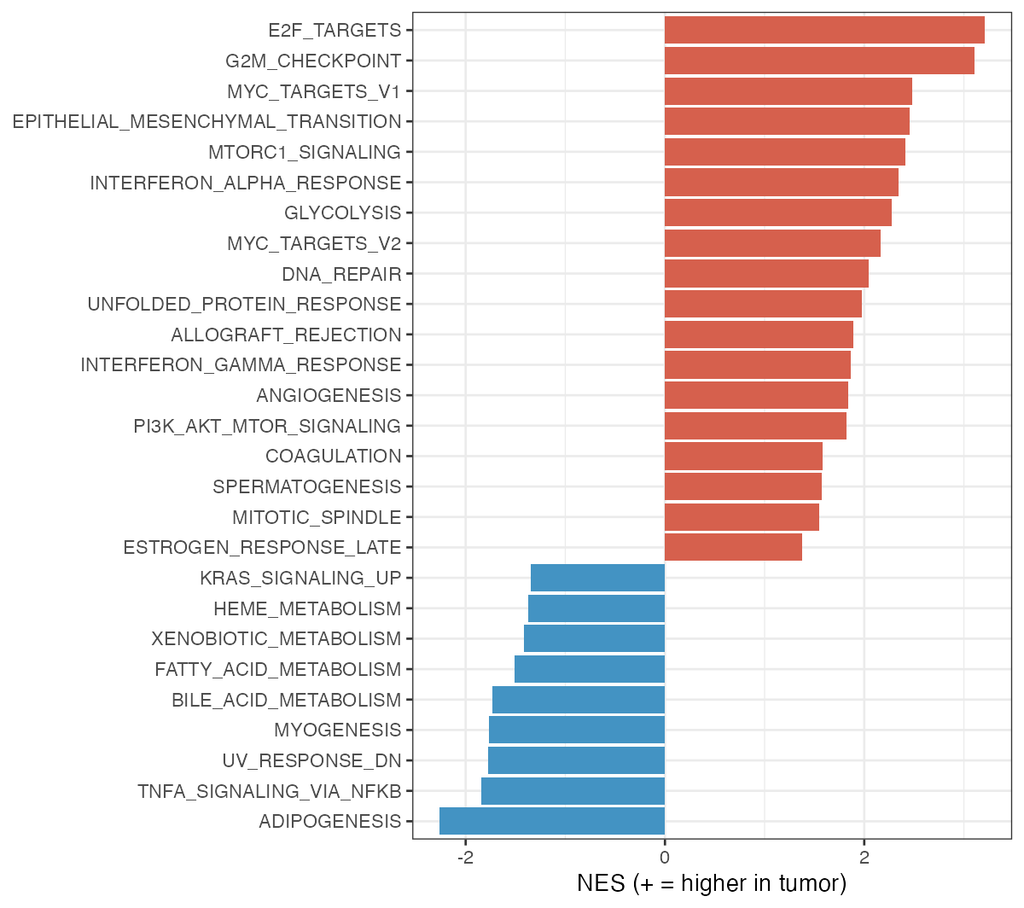

**Figure S10.** Hallmark GSEA (fgsea) of the 11 C5 ERBB2-low tumors vs. matched adjacent normal tissue (paired limma, moderated t). Shown: gene sets with BH-adjusted p < 0.05. Red: higher in tumor.

**Table S31.** MCP-counter cell scores (mean VST of marker genes) in the 11 C5 ERBB2-low tumors and their matched adjacent normal tissue. Mean difference: tumor minus normal, with 95% CI; paired t-test, BH-adjusted across the 10 populations.

| Population | Median, normal | Median, tumor | Mean difference (95% CI) | p | p (BH) |
| --- | --- | --- | --- | --- | --- |
| NK cells | 5.90 | 5.50 | -0.44 (-0.62 to -0.26) | <0.001 | 0.003 |
| Neutrophils | 7.81 | 7.25 | -0.54 (-0.78 to -0.30) | <0.001 | 0.003 |
| Endothelial cells | 9.82 | 8.33 | -1.27 (-1.86 to -0.67) | <0.001 | 0.003 |
| Fibroblasts | 13.16 | 13.69 | +0.83 (0.28 to 1.37) | 0.007 | 0.018 |
| Monocytic lineage | 7.95 | 8.96 | +0.53 (-0.02 to 1.07) | 0.056 | 0.112 |
| Cytotoxic lymphocytes | 6.64 | 6.07 | -0.35 (-0.77 to 0.06) | 0.085 | 0.142 |
| B lineage | 5.88 | 5.57 | -0.29 (-0.72 to 0.14) | 0.165 | 0.218 |
| Myeloid dendritic cells | 6.44 | 6.32 | -0.28 (-0.71 to 0.15) | 0.175 | 0.218 |
| T cells | 6.15 | 6.24 | +0.20 (-0.15 to 0.55) | 0.235 | 0.261 |
| CD8 T cells | 6.32 | 6.49 | +0.12 (-0.48 to 0.71) | 0.669 | 0.669 |

# References

1. Cancer Genome Atlas Network. Comprehensive molecular portraits of human breast tumours. *Nature* 2012;490:61–70. PMID 23000897. DOI: 10.1038/nature11412.
2. Ciriello G, et al. Comprehensive molecular portraits of invasive lobular breast cancer. *Cell* 2015;163:506–519. PMID 26451490. DOI: 10.1016/j.cell.2015.09.033.
3. Aran D, Sirota M, Butte AJ. Systematic pan-cancer analysis of tumour purity. *Nat Commun* 2015;6:8971. PMID 26634437. DOI: 10.1038/ncomms9971.
4. Prat A, Perou CM. Deconstructing the molecular portraits of breast cancer. *Mol Oncol* 2011;5:5–23. PMID 21147047. DOI: 10.1016/j.molonc.2010.11.003.
5. Molania R, et al. Removing unwanted variation from large-scale RNA sequencing data with PRPS. *Nat Biotechnol* 2023;41:82–95. PMID 36109686. DOI: 10.1038/s41587-022-01440-w.
6. Nygaard V, Rødland EA, Hovig E. Methods that remove batch effects while retaining group differences may lead to exaggerated confidence in downstream analyses. *Biostatistics* 2016;17:29–39. PMID 26272994. DOI: 10.1093/biostatistics/kxv027.
7. Wolff AC, et al. American Society of Clinical Oncology/College of American Pathologists guideline recommendations for human epidermal growth factor receptor 2 testing in breast cancer. *J Clin Oncol* 2007;25:118–145. PMID 17159189. DOI: 10.1200/JCO.2006.09.2775.
8. Wolff AC, et al. Recommendations for human epidermal growth factor receptor 2 testing in breast cancer: American Society of Clinical Oncology/College of American Pathologists clinical practice guideline update. *J Clin Oncol* 2013;31:3997–4013. PMID 24101045. DOI: 10.1200/JCO.2013.50.9984.
9. Wolff AC, et al. Human epidermal growth factor receptor 2 testing in breast cancer: American Society of Clinical Oncology/College of American Pathologists clinical practice guideline focused update. *J Clin Oncol* 2018;36:2105–2122. PMID 29846122. DOI: 10.1200/JCO.2018.77.8738.
10. Modi S, et al. Trastuzumab deruxtecan in previously treated HER2-low advanced breast cancer. *N Engl J Med* 2022;387:9–20. PMID 35665782. DOI: 10.1056/NEJMoa2203690.
11. Bardia A, et al. Trastuzumab deruxtecan after endocrine therapy in metastatic breast cancer. *N Engl J Med* 2024;391:2110–2122. PMID 39282896. DOI: 10.1056/NEJMoa2407086.
12. Tarantino P, et al. ESMO expert consensus statements (ECS) on the definition, diagnosis, and management of HER2-low breast cancer. *Ann Oncol* 2023;34:645–659. PMID 37269905. DOI: 10.1016/j.annonc.2023.05.008.
13. Liu J, et al. An integrated TCGA pan-cancer clinical data resource to drive high-quality survival outcome analytics. *Cell* 2018;173:400–416. PMID 29625055. DOI: 10.1016/j.cell.2018.02.052.
14. Parker JS, et al. Supervised risk predictor of breast cancer based on intrinsic subtypes. *J Clin Oncol* 2009;27:1160–1167. PMID 19204204. DOI: 10.1200/JCO.2008.18.1370.
15. Prat A, et al. Molecular features and survival outcomes of the intrinsic subtypes within HER2-positive breast cancer. *J Natl Cancer Inst* 2014;106:dju152. PMID 25139534. DOI: 10.1093/jnci/dju152.
16. Schettini F, et al. Clinical, pathological, and PAM50 gene expression features of HER2-low breast cancer. *NPJ Breast Cancer* 2021;7:1. PMID 33397968. DOI: 10.1038/s41523-020-00208-2.
17. Denkert C, et al. Clinical and molecular characteristics of HER2-low-positive breast cancer: pooled analysis of individual patient data from four prospective, neoadjuvant clinical trials. *Lancet Oncol* 2021;22:1151–1161. PMID 34252375. DOI: 10.1016/S1470-2045(21)00301-6.
18. Cejalvo JM, et al. Intrinsic subtypes and gene expression profiles in primary and metastatic breast cancer. *Cancer Res* 2017;77:2213–2221. PMID 28249905. DOI: 10.1158/0008-5472.CAN-16-2717.
19. Denkert C, et al. Tumour-infiltrating lymphocytes and prognosis in different subtypes of breast cancer: a pooled analysis of 3771 patients treated with neoadjuvant therapy. *Lancet Oncol* 2018;19:40–50. PMID 29233559. DOI: 10.1016/S1470-2045(17)30904-X.
20. Aran D, et al. Comprehensive analysis of normal adjacent to tumor transcriptomes. *Nat Commun* 2017;8:1077. PMID 29057876. DOI: 10.1038/s41467-017-01027-z.
21. Mosele F, et al. Trastuzumab deruxtecan in metastatic breast cancer with variable HER2 expression: the phase 2 DAISY trial. *Nat Med* 2023;29:2110–2120. PMID 37488289. DOI: 10.1038/s41591-023-02478-2.
22. Ogitani Y, et al. Bystander killing effect of DS-8201a, a novel anti-human epidermal growth factor receptor 2 antibody-drug conjugate, in tumors with human epidermal growth factor receptor 2 heterogeneity. *Cancer Sci* 2016;107:1039–1046. PMID 27166974. DOI: 10.1111/cas.12966.
23. Iwata TN, et al. A HER2-targeting antibody-drug conjugate, trastuzumab deruxtecan (DS-8201a), enhances antitumor immunity in a mouse model. *Mol Cancer Ther* 2018;17:1494–1503. PMID 29703841. DOI: 10.1158/1535-7163.MCT-17-0749.
24. Prat A, et al. Prognostic value of intrinsic subtypes in hormone receptor-positive metastatic breast cancer treated with letrozole with or without lapatinib. *JAMA Oncol* 2016;2:1287–1294. PMID 27281556. DOI: 10.1001/jamaoncol.2016.0922.
25. Prat A, et al. Correlative biomarker analysis of intrinsic subtypes and efficacy across the MONALEESA phase III studies. *J Clin Oncol* 2021;39:1458–1467. PMID 33769862. DOI: 10.1200/JCO.20.02977.
26. Fernandez AI, et al. Examination of low ERBB2 protein expression in breast cancer tissue. *JAMA Oncol* 2022;8:607–610. PMID 35113160. DOI: 10.1001/jamaoncol.2021.7239.
27. Dabbs DJ, et al. High false-negative rate of HER2 quantitative reverse transcription polymerase chain reaction of the Oncotype DX test: an independent quality assurance study. *J Clin Oncol* 2011;29:4279–4285. PMID 21990395. DOI: 10.1200/JCO.2011.34.7963.
28. Desmedt C, et al. Genomic characterization of primary invasive lobular breast cancer. *J Clin Oncol* 2016;34:1872–1881. PMID 26926684. DOI: 10.1200/JCO.2015.64.0334.